# Laboratory 2 - Model Engineering

This notebook implements the second lab of the *AI and Cybersecurity* course.

It follows the official brief and develops a full **Machine Learning and Deep Learning pipeline** using PyTorch and PyTorch Geometric to explore, train, and evaluate models for malware classification from API-call sequences.

This lab is organized into tasks:

- Task 1: Frequency-based baseline with sparse API-call count vectors and Logistic Regression
- Task 2: Feed Forward Neural Networks with fixed-length sequences, sequential identifiers, learnable embeddings, and embedding-size analysis
- Task 3: Recurrent models with dynamic padding, Simple RNN, Bidirectional RNN, and Bidirectional LSTM
- Task 4: Graph-based sequence representation and GNN architectures, including GCN, GraphSAGE, and GAT

## Setup

```python
# --- Check Python and pip versions ---
!python --version
!pip install --upgrade pip
```

```
Python 3.12.13
Downloading pip-26.1.2-py3-none-any.whl (1.8 MB)
   ━━━━━━━━━━━━━━━━━━━━━━━━━━━━━━━━━━━━━━━━ 1.8/1.8 MB 20.8 MB/s eta 0:00:00
  Attempting uninstall: pip
    Found existing installation: pip 24.1.2
    Uninstalling pip-24.1.2:
      Successfully uninstalled pip-24.1.2
```

```python
# --- Install required libraries ---
!pip install torch
!pip install numpy pandas scikit-learn matplotlib seaborn
!pip install tqdm
!pip install torch_geometric
# torch_sparse torch_scatter # TODO: check
```

```
Downloading torch_geometric-2.8.0-py3-none-any.whl (1.3 MB)
   ━━━━━━━━━━━━━━━━━━━━━━━━━━━━━━━━━━━━━━━━ 1.3/1.3 MB 8.8 MB/s  0:00:00
```

```python
# --- Import libraries ---
import os
import time
import random
import numpy as np
import pandas as pd
import matplotlib.pyplot as plt
import seaborn as sns
import json
import math

from sklearn.model_selection import train_test_split
from sklearn.linear_model import LogisticRegression
from sklearn.metrics import accuracy_score
from sklearn.preprocessing import StandardScaler, MinMaxScaler, RobustScaler, LabelEncoder
from sklearn.utils.class_weight import compute_class_weight
from sklearn.metrics import classification_report, confusion_matrix, accuracy_score, f1_score, log_loss
from sklearn.decomposition import PCA
from sklearn.impute import SimpleImputer

import torch
import torch.nn as nn
import torch.nn.functional as F
import torch.optim as optim
from torch.utils.data import Dataset, DataLoader, TensorDataset
from torch.nn.utils.rnn import pad_sequence, pack_padded_sequence, pad_packed_sequence
import torch_geometric
from torch_geometric.nn import GCNConv, SAGEConv, GATConv, global_mean_pool, global_max_pool
from torch_geometric.loader import DataLoader as PyGDataLoader
from torch_geometric.utils import to_networkx
from torch_geometric.data import Data

import networkx as nx

from tqdm import tqdm
```

### Runtime Check

```python
# --- Check GPU availability ---
gpu_info = !nvidia-smi
gpu_info = '\n'.join(gpu_info)
if gpu_info.find('failed') >= 0:
  print('Not connected to a GPU')
else:
  print(gpu_info)
```

```
Wed Jun 17 08:07:06 2026
+-----------------------------------------------------------------------------------------+
| NVIDIA-SMI 580.82.07              Driver Version: 580.82.07      CUDA Version: 13.0     |
+-----------------------------------------+------------------------+----------------------+
| GPU  Name                 Persistence-M | Bus-Id          Disp.A | Volatile Uncorr. ECC |
| Fan  Temp   Perf          Pwr:Usage/Cap |           Memory-Usage | GPU-Util  Compute M. |
|                                         |                        |               MIG M. |
|=========================================+========================+======================|
|   0  Tesla T4                       Off |   00000000:00:04.0 Off |                    0 |
| N/A   32C    P8              9W /   70W |       3MiB /  15360MiB |      0%      Default |
|                                         |                        |                  N/A |
+-----------------------------------------+------------------------+----------------------+

+-----------------------------------------------------------------------------------------+
| Processes:                                                                              |
|  GPU   GI   CI              PID   Type   Process name                        GPU Memory |
|        ID   ID                                                               Usage      |
|=========================================================================================|
|  No running processes found                                                             |
+-----------------------------------------------------------------------------------------+
```

```python
# --- Check RAM availability ---
from psutil import virtual_memory
ram_gb = virtual_memory().total / 1e9
print('Your runtime has {:.1f} gigabytes of available RAM\n'.format(ram_gb))

if ram_gb < 20:
  print('Not using a high-RAM runtime')
else:
  print('You are using a high-RAM runtime!')
```

```
Your runtime has 13.6 gigabytes of available RAM

Not using a high-RAM runtime
```

### Paths setup

```python
# --- Local notebook: Google Drive is not required ---
# Paths are configured in the next cell relative to the Laboratory2 project folder.
print("Running local version: Google Drive mount skipped.")
```

```python
# --- Define local paths ---
from pathlib import Path

def find_laboratory2_root(start=None):
    """Find the Laboratory2 project root from the current notebook/session path."""
    candidates = []

    if start is not None:
        candidates.append(Path(start).resolve())

    # In a normal Jupyter session, the current working directory is enough.
    candidates.append(Path.cwd().resolve())

    # If the notebook is launched from another folder, also inspect common relative roots.
    candidates.extend([
        Path.cwd().resolve() / "Laboratory2",
        Path.cwd().resolve().parent,
        Path.cwd().resolve().parent.parent,
    ])

    for candidate in candidates:
        for parent in [candidate, *candidate.parents]:
            data_dir = parent / "lab" / "data"
            if (data_dir / "train.json").exists() and (data_dir / "test.json").exists():
                return parent

    raise FileNotFoundError(
        "Could not locate Laboratory2/lab/data/train.json and test.json. "
        "Run the notebook from inside the Laboratory2 project or keep the lab/data folder structure."
    )

project_root = find_laboratory2_root()
project_path = str(project_root) + os.sep
data_path = str(project_root / "lab" / "data") + os.sep
results_path = str(project_root / "results") + os.sep

# Ensure output directories exist.
os.makedirs(results_path, exist_ok=True)

print(f"Project path: {project_path}")
print(f"Data path: {data_path}")
print(f"Results path: {results_path}")
```

[output not shown]

```python
# --- Set visual style ---
# Plot style tuned for report figures: the figure size stays compact,
# while axes, tick labels, legends, and titles remain readable after LaTeX scaling.
REPORT_PLOT_TITLE_SIZE = 16
REPORT_PLOT_LABEL_SIZE = 14
REPORT_PLOT_TICK_SIZE = 12
REPORT_PLOT_LEGEND_SIZE = 12
REPORT_PLOT_LINEWIDTH = 2.3

sns.set_theme(
    style="whitegrid",
    palette="muted",
    font_scale=1.15,
    rc={
        "axes.titlesize": REPORT_PLOT_TITLE_SIZE,
        "axes.labelsize": REPORT_PLOT_LABEL_SIZE,
        "xtick.labelsize": REPORT_PLOT_TICK_SIZE,
        "ytick.labelsize": REPORT_PLOT_TICK_SIZE,
        "legend.fontsize": REPORT_PLOT_LEGEND_SIZE,
        "figure.dpi": 120,
        "savefig.dpi": 300,
    },
)

plt.rcParams.update({
    "axes.titlesize": REPORT_PLOT_TITLE_SIZE,
    "axes.labelsize": REPORT_PLOT_LABEL_SIZE,
    "xtick.labelsize": REPORT_PLOT_TICK_SIZE,
    "ytick.labelsize": REPORT_PLOT_TICK_SIZE,
    "legend.fontsize": REPORT_PLOT_LEGEND_SIZE,
})

def format_report_axes(ax, legend=True, legend_loc="best"):
    """Make plot text readable after the figure is scaled inside the report."""
    ax.tick_params(axis="both", labelsize=REPORT_PLOT_TICK_SIZE)
    ax.xaxis.label.set_size(REPORT_PLOT_LABEL_SIZE)
    ax.yaxis.label.set_size(REPORT_PLOT_LABEL_SIZE)
    ax.title.set_size(REPORT_PLOT_TITLE_SIZE)

    handles, labels = ax.get_legend_handles_labels()
    current_legend = ax.get_legend()
    if legend and handles and current_legend is None:
        current_legend = ax.legend(fontsize=REPORT_PLOT_LEGEND_SIZE, loc=legend_loc, frameon=True)
    elif current_legend is not None:
        for text in current_legend.get_texts():
            text.set_fontsize(REPORT_PLOT_LEGEND_SIZE)
        current_legend.set_frame_on(True)
    return ax

def save_plot(fig: plt.Figure, filename: str, path: str = "./plots/", fmt: str = "png", dpi: int = 300, close_fig: bool = False) -> None:
    """
    Save a Matplotlib figure in a specific to a specified directory.

    Args:
        fig (plt.Figure): Matplotlib figure object to save.
        filename (str): Name of the file to save (e.g., 'plot.png').
        path (str, optional): Directory path to save the figure. Defaults to './plots/'.
        fmt (str, optional): File format for the saved figure. Defaults to 'png'.
        dpi (int, optional): Dots per inch for the saved figure. Defaults to 300.

    Returns:
        None
    """
    # Ensure the directory exists
    os.makedirs(path, exist_ok=True)
    save_path = os.path.join(path, f"{filename}.{fmt}")

    # Save the figure
    fig.savefig(save_path, bbox_inches='tight', pad_inches=0.18, dpi=dpi, format=fmt)
    # plt.close(fig) # Removed to display plots in notebook

    if close_fig:
        plt.close(fig)

    print(f"Saved plot: {save_path}")
```

```python
def _internal_plot_cm(y_true, y_pred, model_name, save_dir):
    """Internal helper to draw the confusion matrix plot."""
    cm = confusion_matrix(y_true, y_pred)

    # Create figure explicitly
    fig, ax = plt.subplots(figsize=(5, 4))

    sns.heatmap(
        cm,
        annot=True,
        fmt='d',
        cmap='Blues',
        cbar=False,
        xticklabels=['Benign (0)', 'Malware (1)'],
        yticklabels=['Benign (0)', 'Malware (1)'],
        ax=ax
    )

    ax.set_xlabel('Predicted Label', fontsize=12)
    ax.set_ylabel('True Label', fontsize=12)
    ax.set_title(f'Confusion Matrix: {model_name}', fontsize=14)

    if save_dir:
        clean_name = model_name.lower().replace(" ", "_").replace("-", "_")
        save_plot(
            fig=fig,
            filename=f"cm_{clean_name}",
            path=save_dir,
            fmt="png",
            dpi=300,
            close_fig=False
        )

    plt.show()
```

## Task 1 — Frequency-based baseline

We implement a simple frequency-based baseline.

- Transform sequences into feature vectors counting API call occurrences.
- Helps evaluate whether simple approaches already perform well before using complex models.

```python
# Create directory for plots
save_dir = results_path + 'images/' + 'task1_plots/'
os.makedirs(save_dir, exist_ok=True)
```

### Frequency-Based Approach

- Extract vocabulary from train and test datasets.
- Use vocabulary to create feature vectors (frequency counts per API call).
- Output dataframe: one row per sequence, one column per API call.

```python
# --- Load dataset and perform initial inspection ---

# Train set
file_path_train = data_path + 'train.json'
df_train = pd.read_json(file_path_train)

# Basic info
print("Train set:")
print("  Shape (raw):", df_train.shape)
print("  Columns:", list(df_train.columns))

# Test set
file_path_test = data_path + 'test.json'
df_test = pd.read_json(file_path_test)

# Basic info
print("\nTest set:")
print("  Shape (raw):", df_test.shape)
print("  Columns:", list(df_test.columns))
```

```
Train set:
  Shape (raw): (16325, 2)
  Columns: ['api_call_sequence', 'is_malware']

Test set:
  Shape (raw): (6505, 2)
  Columns: ['api_call_sequence', 'is_malware']
```

```python
df_train
```

|  | api_call_sequence | is_malware |
| --- | --- | --- |
| 0 | [LdrGetDllHandle, LdrGetProcedureAddress, LdrL... | 1 |
| 1 | [NtAllocateVirtualMemory, LdrLoadDll, LdrGetPr... | 1 |
| 2 | [FindResourceExW, LoadResource, FindResourceEx... | 1 |
| 3 | [FindResourceExW, LoadResource, FindResourceEx... | 1 |
| 4 | [LdrGetProcedureAddress, SetErrorMode, LdrLoad... | 1 |
| ... | ... | ... |
| 16320 | [LdrGetProcedureAddress, LdrLoadDll, LdrGetPro... | 1 |
| 16321 | [NtClose, LdrGetProcedureAddress, CryptCreateH... | 1 |
| 16322 | [LdrGetProcedureAddress, LdrGetDllHandle, LdrG... | 1 |
| 16323 | [LdrGetProcedureAddress, LdrGetDllHandle, LdrG... | 1 |
| 16324 | [SetFilePointer, NtReadFile, SetFilePointer, N... | 1 |

16325 rows × 2 columns

```python
malware_counts = df_train['is_malware'].value_counts()
num_total_samples = len(df_train)

print("Malware vs. Benign Samples in Training Set:")
print(malware_counts)

print("\nPercentages:")
for is_malware, count in malware_counts.items():
    percentage = (count / num_total_samples) * 100
    if is_malware == 1:
        print(f"  Malware (1): {count} samples ({percentage:.2f}%) - {(count / num_total_samples)*100:.2f}% of total")
    else:
        print(f"  Benign (0): {count} samples ({percentage:.2f}%) - {(count / num_total_samples)*100:.2f}% of total")
```

```
Malware vs. Benign Samples in Training Set:
is_malware
1    15714
0      611
Name: count, dtype: int64

Percentages:
  Malware (1): 15714 samples (96.26%) - 96.26% of total
  Benign (0): 611 samples (3.74%) - 3.74% of total
```

```python
df_test
```

|  | api_call_sequence | is_malware |
| --- | --- | --- |
| 0 | [NtQueryValueKey, NtClose, NtOpenKey, NtQueryV... | 1 |
| 1 | [LdrGetProcedureAddress, NtClose, NtOpenKey, N... | 1 |
| 2 | [NtOpenKey, NtQueryValueKey, NtClose, NtOpenKe... | 1 |
| 3 | [NtAllocateVirtualMemory, LdrLoadDll, LdrGetPr... | 1 |
| 4 | [NtOpenKey, NtQueryValueKey, NtClose, LdrGetPr... | 1 |
| ... | ... | ... |
| 6500 | [SetErrorMode, NtOpenFile, NtClose, SHGetFolde... | 0 |
| 6501 | [NtProtectVirtualMemory, RegOpenKeyExW, RegQue... | 1 |
| 6502 | [RegOpenKeyExW, RegQueryValueExW, RegCloseKey,... | 1 |
| 6503 | [NtQueryValueKey, NtClose, RegOpenKeyExA, RegQ... | 1 |
| 6504 | [NtClose, LdrGetProcedureAddress, CryptCreateH... | 1 |

6505 rows × 2 columns

```python
malware_counts = df_test['is_malware'].value_counts()
num_total_samples = len(df_test)

print("Malware vs. Benign Samples in Test Set:")
print(malware_counts)

print("\nPercentages:")
for is_malware, count in malware_counts.items():
    percentage = (count / num_total_samples) * 100
    if is_malware == 1:
        print(f"  Malware (1): {count} samples ({percentage:.2f}%) - {(count / num_total_samples)*100:.2f}% of total")
    else:
        print(f"  Benign (0): {count} samples ({percentage:.2f}%) - {(count / num_total_samples)*100:.2f}% of total")
```

```
Malware vs. Benign Samples in Test Set:
is_malware
1    6262
0     243
Name: count, dtype: int64

Percentages:
  Malware (1): 6262 samples (96.26%) - 96.26% of total
  Benign (0): 243 samples (3.74%) - 3.74% of total
```

### Extract the vocabularies

```python
# Extract vocabulary from training set
train_vocab = set(api_call for seq in df_train['api_call_sequence'] for api_call in seq)

# Count unique API calls
print(f"Train: {len(train_vocab)}")
```

```
Train: 258
```

```python
# Extract vocabulary from test set
test_vocab = set(api_call for seq in df_test['api_call_sequence'] for api_call in seq)

# Count unique API calls
print(f"Test: {len(test_vocab)}")
```

```
Test: 232
```

#### Q: How many unique API calls does the training set contain? How many in the test set?

- **Training set**: there are **258 unique API calls**.
- **Test set**: there are **232 unique API calls**.

```python
# --- Find API calls only in the training set ---

only_in_train = train_vocab - test_vocab

# Count and print them
print(f"Number of API calls only in training set: {len(only_in_train)}")
print("API calls only in training set:", only_in_train)
```

```
Number of API calls only in training set: 29
API calls only in training set: {'InternetSetStatusCallback', 'GetFileInformationByHandleEx', 'IWbemServices_ExecMethod', 'CreateRemoteThread', 'CryptProtectMemory', 'CertOpenSystemStoreW', 'CryptDecodeObjectEx', 'NtReadVirtualMemory', 'RtlRemoveVectoredExceptionHandler', 'FindFirstFileExA', 'Intern…
```

```python
# --- Find API calls only in the test set ---

only_in_test = test_vocab - train_vocab

# Count and print them
print(f"Number of API calls only in test set: {len(only_in_test)}")
print("API calls only in test set:", only_in_test)
```

```
Number of API calls only in test set: 3
API calls only in test set: {'WSASocketA', 'NtDeleteKey', 'ControlService'}
```

```python
# Create a boolean series to identify samples in df_test that contain any of these API calls
has_test_only_apis = df_test['api_call_sequence'].apply(
    lambda seq: any(api in only_in_test for api in seq)
)

# Count the samples
samples_with_test_only_apis = has_test_only_apis.sum()

print(f"Number of test set samples with API calls unique to the test set: {samples_with_test_only_apis}")

# Display the actual rows
print("\nTest samples containing API calls unique to the test set:")
display(df_test[has_test_only_apis])
```

```
Number of test set samples with API calls unique to the test set: 3

Test samples containing API calls unique to the test set:
```

|  | api_call_sequence | is_malware |
| --- | --- | --- |
| 2873 | [LdrGetDllHandle, LdrGetProcedureAddress, LdrG... | 1 |
| 4105 | [NtProtectVirtualMemory, CreateThread, NtAlloc... | 1 |
| 5948 | [NtDelayExecution, gethostbyname, NtDelayExecu... | 1 |

#### Q: Are there any API calls that appear only in the test set (but not in the training set)? If yes, how many? Which ones?

Yes — there are API calls that appear only in the test set and not in the training set.

- **Number of such API calls**: 3
- **API calls only in the test set**: `NtDeleteKey`, `ControlService`, `WSASocketA`

### New frequency-based dataframes

- Create dataframe using training vocabulary as features.
- Count occurrences of each API call per sequence.

```python
# Create frequency-based dataframe for training data
train_df_freq = pd.DataFrame([{api: seq.count(api) for api in train_vocab} for seq in df_train['api_call_sequence']])
```

```python
# Dataframe characteristics
print("Shape (raw):", train_df_freq.shape)
print("Columns:", list(train_df_freq.columns))
```

```
Shape (raw): (16325, 258)
Columns: ['InternetSetStatusCallback', 'GetFileInformationByHandleEx', 'DrawTextExA', 'GetVolumePathNamesForVolumeNameW', 'getaddrinfo', 'RemoveDirectoryW', 'RegisterHotKey', 'DeleteUrlCacheEntryW', 'NtCreateSection', 'CryptHashData', 'LookupPrivilegeValueW', 'RegCreateKeyExW', 'GetFileVersionInfoEx…
```

```python
train_df_freq.head(10)
```

|  | InternetSetStatusCallback | GetFileInformationByHandleEx | DrawTextExA | GetVolumePathNamesForVolumeNameW | getaddrinfo | RemoveDirectoryW | RegisterHotKey | DeleteUrlCacheEntryW | NtCreateSection | CryptHashData | ... | CreateProcessInternalW | NtWriteFile | NtOpenKeyEx | DeleteFileW | GetTimeZoneInformation | __exception__ | CreateDirectoryW | NtOpenProcess | setsockopt | NtReadFile |
| --- | --- | --- | --- | --- | --- | --- | --- | --- | --- | --- | --- | --- | --- | --- | --- | --- | --- | --- | --- | --- | --- |
| 0 | 0 | 0 | 0 | 0 | 0 | 0 | 0 | 0 | 0 | 0 | ... | 0 | 0 | 0 | 0 | 1 | 0 | 0 | 0 | 0 | 0 |
| 1 | 0 | 0 | 0 | 0 | 0 | 0 | 0 | 0 | 0 | 0 | ... | 0 | 0 | 5 | 0 | 0 | 0 | 0 | 0 | 0 | 0 |
| 2 | 0 | 0 | 0 | 0 | 0 | 0 | 0 | 0 | 0 | 0 | ... | 0 | 0 | 0 | 0 | 0 | 0 | 0 | 0 | 0 | 0 |
| 3 | 0 | 0 | 0 | 0 | 0 | 0 | 0 | 0 | 1 | 0 | ... | 0 | 0 | 0 | 0 | 0 | 0 | 0 | 0 | 0 | 0 |
| 4 | 0 | 0 | 0 | 0 | 0 | 0 | 0 | 0 | 0 | 0 | ... | 0 | 0 | 0 | 0 | 0 | 0 | 0 | 0 | 0 | 0 |
| 5 | 0 | 0 | 0 | 0 | 0 | 0 | 0 | 0 | 1 | 0 | ... | 0 | 0 | 0 | 0 | 0 | 0 | 0 | 0 | 0 | 0 |
| 6 | 0 | 0 | 0 | 0 | 0 | 0 | 0 | 0 | 0 | 0 | ... | 0 | 0 | 0 | 0 | 0 | 0 | 0 | 1 | 0 | 0 |
| 7 | 0 | 0 | 0 | 0 | 0 | 0 | 0 | 0 | 1 | 0 | ... | 0 | 0 | 0 | 0 | 0 | 0 | 0 | 0 | 0 | 0 |
| 8 | 0 | 0 | 0 | 0 | 0 | 0 | 0 | 0 | 1 | 0 | ... | 0 | 0 | 0 | 0 | 0 | 0 | 0 | 0 | 0 | 0 |
| 9 | 0 | 0 | 0 | 0 | 0 | 0 | 0 | 0 | 0 | 0 | ... | 0 | 0 | 0 | 0 | 0 | 0 | 0 | 0 | 0 | 0 |

10 rows × 258 columns

```python
# Create frequency-based dataframe for test data
test_df_freq = pd.DataFrame([{api: seq.count(api) for api in test_vocab} for seq in df_test['api_call_sequence']])
```

```python
# Dataframe characteristics
print("Shape (raw):", test_df_freq.shape)
print("Columns:", list(test_df_freq.columns))
```

```
Shape (raw): (6505, 232)
Columns: ['DrawTextExA', 'GetVolumePathNamesForVolumeNameW', 'getaddrinfo', 'RemoveDirectoryW', 'RegisterHotKey', 'DeleteUrlCacheEntryW', 'NtCreateSection', 'CryptHashData', 'LookupPrivilegeValueW', 'RegCreateKeyExW', 'GetFileVersionInfoExW', 'GetAdaptersInfo', 'GetFileVersionInfoW', 'NtCreateFile',…
```

```python
test_df_freq.head(10)
```

|  | DrawTextExA | GetVolumePathNamesForVolumeNameW | getaddrinfo | RemoveDirectoryW | RegisterHotKey | DeleteUrlCacheEntryW | NtCreateSection | CryptHashData | LookupPrivilegeValueW | RegCreateKeyExW | ... | CreateProcessInternalW | NtWriteFile | NtOpenKeyEx | DeleteFileW | GetTimeZoneInformation | __exception__ | CreateDirectoryW | NtOpenProcess | setsockopt | NtReadFile |
| --- | --- | --- | --- | --- | --- | --- | --- | --- | --- | --- | --- | --- | --- | --- | --- | --- | --- | --- | --- | --- | --- |
| 0 | 0 | 0 | 0 | 0 | 0 | 0 | 1 | 0 | 0 | 0 | ... | 0 | 0 | 0 | 0 | 0 | 0 | 0 | 0 | 0 | 0 |
| 1 | 0 | 0 | 0 | 0 | 0 | 0 | 1 | 0 | 0 | 0 | ... | 0 | 0 | 0 | 0 | 0 | 0 | 0 | 0 | 0 | 13 |
| 2 | 0 | 0 | 0 | 0 | 0 | 0 | 0 | 0 | 0 | 0 | ... | 0 | 0 | 0 | 0 | 1 | 0 | 0 | 0 | 0 | 0 |
| 3 | 0 | 0 | 0 | 0 | 0 | 0 | 1 | 0 | 0 | 0 | ... | 0 | 0 | 0 | 0 | 0 | 0 | 0 | 0 | 0 | 0 |
| 4 | 0 | 0 | 0 | 0 | 0 | 0 | 0 | 1 | 0 | 1 | ... | 0 | 0 | 0 | 0 | 0 | 0 | 0 | 0 | 0 | 1 |
| 5 | 0 | 0 | 0 | 0 | 0 | 0 | 0 | 0 | 0 | 0 | ... | 0 | 0 | 0 | 0 | 0 | 0 | 0 | 0 | 0 | 0 |
| 6 | 0 | 0 | 0 | 0 | 0 | 0 | 0 | 1 | 0 | 1 | ... | 0 | 0 | 0 | 0 | 0 | 0 | 0 | 0 | 0 | 1 |
| 7 | 0 | 0 | 0 | 0 | 0 | 0 | 0 | 0 | 0 | 0 | ... | 0 | 0 | 0 | 0 | 0 | 0 | 0 | 0 | 0 | 0 |
| 8 | 0 | 0 | 0 | 0 | 0 | 0 | 0 | 0 | 0 | 0 | ... | 0 | 0 | 0 | 0 | 0 | 0 | 0 | 0 | 0 | 0 |
| 9 | 0 | 0 | 0 | 0 | 0 | 0 | 0 | 1 | 0 | 1 | ... | 0 | 0 | 0 | 0 | 0 | 0 | 0 | 0 | 0 | 1 |

10 rows × 232 columns

#### Q: Can you use the test vocabulary to build the new test dataframe? If not, how do you handle API calls in the test set that do not exist in the training vocabulary?

No, you cannot use the test vocabulary to build the test dataframe.

Machine learning models require the feature space (columns) during inference (testing) to be identical to the feature space used during training.

Common strategies for handling API calls in the test set that did not exist in the training vocabulary include:

1. **Add an "Unknown" Column**: Map all unseen API calls to a single generic token (e.g., `<UNK>`) or a specific "is_unknown" feature. This preserves the information that *an* action occurred, even if the specific action is unrecognized.
2. **Ignore Them**: Simply discard or zero-out any API calls that were not seen during training.

**Decision**: In this specific case, since there are **very few unseen API calls** (i.e. *only 3* samples) in the test set, we decided to **ignore them**. This approach simplifies the pipeline without significantly impacting the model's performance.

#### Sparse Vectors Analysis

```python
# --- Non-zero elements analysis for training data ---

# Calculate average non-zero elements per row
avg_nonzero_train = (train_df_freq != 0).sum(axis=1).mean()
print(f"Average non-zero elements per row in train_df_freq: {avg_nonzero_train:.2f}")

# Calculate ratio of non-zero elements
ratio_nonzero_train = avg_nonzero_train / train_df_freq.shape[1]
print(f"Ratio of non-zero elements per row in train_df_freq: {ratio_nonzero_train:.4f}")
```

```
Average non-zero elements per row in train_df_freq: 21.95
Ratio of non-zero elements per row in train_df_freq: 0.0851
```

```python
# --- Non-zero elements analysis for test data ---

# Calculate average non-zero elements per row
avg_nonzero_test = (test_df_freq != 0).sum(axis=1).mean()
print(f"Average non-zero elements per row in test_df_freq: {avg_nonzero_test:.2f}")

# Calculate ratio of non-zero elements
ratio_nonzero_test = avg_nonzero_test / test_df_freq.shape[1]
print(f"Ratio of non-zero elements per row in test_df_freq: {ratio_nonzero_test:.4f}")
```

```
Average non-zero elements per row in test_df_freq: 24.28
Ratio of non-zero elements per row in test_df_freq: 0.1046
```

#### Q: How many non-zero elements per row do you have on average in the training set? How many in the test set? What is the ratio with respect to the number of elements per row?

On average:

- **Training set**: ~22 non-zero elements per row, which is **8.5%** of all elements.
- **Test set**: ~24 non-zero elements per row, which is **10.5%** of all elements.

#### Q: The original API sequences were ordered. Is it still the case now in the frequency-based dataframe? Why?

No, the original order of API calls is **not preserved** in the frequency-based dataframe.

This is because the frequency-based representation **counts how many times each API call occurs** in a sequence, without keeping track of their positions. Each row now simply contains **one column per API call in the vocabulary**, with the value representing its count, so the sequential order is lost.

This approach converts sequences into fixed-dimensional vectors, simplifying the computation but discarding temporal information. As a result, complex behavioral patterns based on the chronology of calls cannot be captured by this representation.

### Feed the frequency-based datasets to a classifier

- Any classifier can be used (shallow/deep neural or non-neural).
- Goal: evaluate baseline performance on sparse vectors without sequence information.

#### Training

```python
# --- Training with a classifier ---

# Split data into features and target
X = train_df_freq
y = df_train['is_malware']

# Create a validation set from training set
X_train, X_val, y_train, y_val = train_test_split(
    X, y, test_size=0.4, random_state=42, stratify=y
)

# Construct test set with features aligned to train_vocab
# TODO: justify this strategy in the report (too few samples)
X_test = pd.DataFrame([{api: seq.count(api) for api in train_vocab} for seq in df_test['api_call_sequence']])
y_test = df_test['is_malware']

# Train a simple classifier (using default hyperparameters for a simple baseline)
clf = LogisticRegression(random_state=42, solver='liblinear') # 'liblinear' solver is good for small datasets and sparse data
clf.fit(X_train, y_train)

# Compute training and validation loss
y_train_proba = clf.predict_proba(X_train)
y_val_proba = clf.predict_proba(X_val)

print(f"Training log-loss: {log_loss(y_train, y_train_proba):.4f}")
print(f"Validation log-loss: {log_loss(y_val, y_val_proba):.4f}")
```

```
Training log-loss: 0.0806
Validation log-loss: 0.1225
```

#### Evaluation

```python
def evaluate_model(model, X, y_true, model_name: str = "Unnamed model"):
    """
    Evaluate a trained scikit-learn model on a given dataset and return the classification report.
    Handles missing predicted classes gracefully (zero_division=0).
    """
    # Get predictions
    y_pred = model.predict(X)

    # Identify missing classes (not predicted at all)
    missing_classes = set(np.unique(y_true)) - set(np.unique(y_pred))
    if missing_classes:
        missing_classes = [int(x) for x in sorted(missing_classes)]
        print(f"Warning: {model_name} made no predictions for classes: {missing_classes}")

    # Generate classification report
    report = classification_report(y_true, y_pred, digits=4, zero_division=0)

    return report
```

```python
def plot_cm_task1(model, X_test, y_test, model_name, save_dir=None):
    """
    Specific for Task 1 (Scikit-Learn models).
    Generates predictions using .predict() and then plots.
    """
    # 1. Get predictions (Scikit-learn models work directly on X_test)
    y_pred = model.predict(X_test)

    # 2. Use the core helper to plot
    # Note: y_test might need to be converted to a simple list/array if it's a pandas Series
    _internal_plot_cm(y_test, y_pred, model_name, save_dir)
```

```python
# --- Evaluate validation and test set and print classification reports ---

print(f"\nValidation classification report:\n")
report = evaluate_model(clf, X_val, y_val, "Logistic Regression (Validation)")
print(report)

print(f"\nTest classification report:\n")
report = evaluate_model(clf, X_test, y_test, "Logistic Regression (Test)")
print(report)
```

```
Validation classification report:

              precision    recall  f1-score   support

           0     0.6750    0.3320    0.4451       244
           1     0.9746    0.9938    0.9841      6286

    accuracy                         0.9691      6530
   macro avg     0.8248    0.6629    0.7146      6530
weighted avg     0.9634    0.9691    0.9639      6530


Test classification report:

              precision    recall  f1-score   support

           0     0.6885    0.3457    0.4603       243
           1     0.9751    0.9939    0.9844      6262

    accuracy                         0.9697      6505
   macro avg     0.8318    0.6698    0.7223      6505
weighted avg     0.9644    0.9697    0.9648      6505
```

```
Saved plot: /content/drive/MyDrive/Projects/AImSecure/Laboratory2/results/images/task1_plots/cm_frequency_baseline_val.png
```

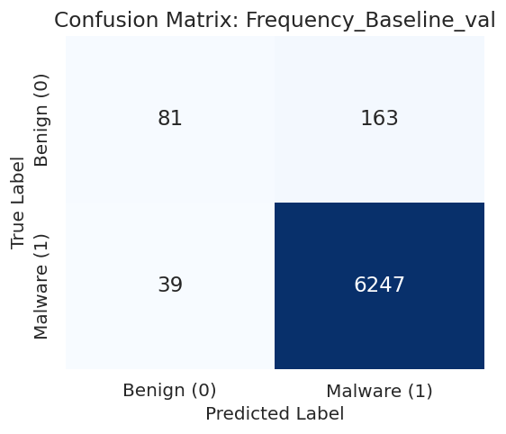

```python
plot_cm_task1(
    model=clf,
    X_test=X_val,
    y_test=y_val,
    model_name="Frequency_Baseline_val",
    save_dir=results_path + 'images/task1_plots/'
)
```

```
Saved plot: /content/drive/MyDrive/Projects/AImSecure/Laboratory2/results/images/task1_plots/cm_frequency_baseline_test.png
```

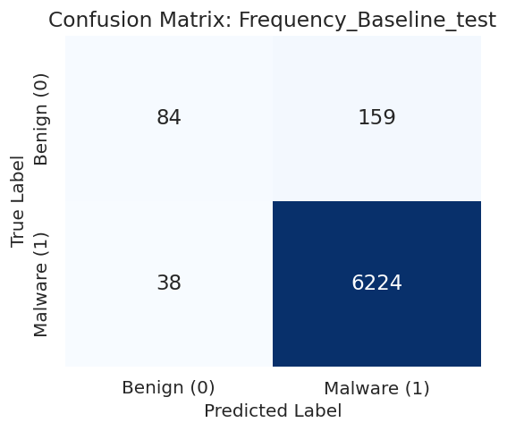

```python
plot_cm_task1(
    model=clf,
    X_test=X_test,
    y_test=y_test,
    model_name="Frequency_Baseline_test",
    save_dir=results_path + 'images/task1_plots/'
)
```

#### Q: Report how you chose the hyperparameters of your classifier, and the final performance on the test set.

We used Logistic Regression as a deliberately simple frequency-based baseline. This choice is useful because the goal of Task 1 is not to maximize complexity, but to understand how much discriminative information is already contained in API-call counts before introducing sequence-aware models.

The model was trained with the `liblinear` solver, default L2 regularization (`C=1.0`), no class weighting, and `random_state=42` for reproducibility. We did not perform an extensive hyperparameter search at this stage, because the classifier is meant to be a stable reference point for the later FFNN, RNN, and GNN experiments.

The final test performance is strong in terms of global accuracy: the model reaches `96.97%` accuracy and macro F1 `0.7223`. However, the class-wise report shows a clear imbalance effect. Malware is detected very well, with precision `0.9751` and recall `0.9939`, while the benign class has good precision (`0.6885`) but low recall (`0.3457`). Therefore, the baseline is effective at identifying malware, but it tends to classify many benign samples as malware.

#### Q: Is the final performance good, even ignoring the order of API calls and handling very sparse vectors?

Yes, the final performance is good for a simple frequency-based baseline. Even though the representation is sparse and completely discards the order of API calls, the model still reaches `96.97%` accuracy and macro F1 `0.7223` on the test set. This indicates that the presence and frequency of API calls already contain substantial information for distinguishing malware from benign software.

At the same time, the per-class metrics show the limitation of this approach. The model obtains excellent malware recall (`0.9939`), but benign recall is only `0.3457`. This means that the high accuracy is partly driven by the majority malware class. The baseline is therefore useful and competitive, but not fully balanced: later models should try to improve minority-class recall and macro F1, even if this slightly reduces overall accuracy.

## Task 2 - Feed Forward Neural Network (FFNN)

```python
# Create directory for plots
save_dir = results_path + 'images/' + 'task2_plots/'
os.makedirs(save_dir, exist_ok=True)
```

### API Call Statistics

```python
# --- Compute the length (number of API calls) per sequence ---
df_train['seq_length'] = df_train['api_call_sequence'].apply(len)
df_test['seq_length'] = df_test['api_call_sequence'].apply(len)

# --- Basic descriptive statistics ---
print("Train set sequence length stats:")
print(df_train['seq_length'].describe(), "\n")

print("Test set sequence length stats:")
print(df_test['seq_length'].describe(), "\n")

# --- Check if all sequences have the same length ---
same_length_train = df_train['seq_length'].nunique() == 1
same_length_test = df_test['seq_length'].nunique() == 1
print(f"All train sequences same length? {same_length_train}")
print(f"All test sequences same length? {same_length_test}\n")
```

```
Train set sequence length stats:
count    16325.000000
mean        75.030812
std          8.951411
min         60.000000
25%         67.000000
50%         75.000000
75%         83.000000
max         90.000000
Name: seq_length, dtype: float64

Test set sequence length stats:
count    6505.000000
mean       86.331130
std         9.113511
min        70.000000
25%        79.000000
50%        87.000000
75%        94.000000
max       100.000000
Name: seq_length, dtype: float64

All train sequences same length? False
All test sequences same length? False
```

```python
df_train
```

|  | api_call_sequence | is_malware | seq_length |
| --- | --- | --- | --- |
| 0 | [LdrGetDllHandle, LdrGetProcedureAddress, LdrL... | 1 | 73 |
| 1 | [NtAllocateVirtualMemory, LdrLoadDll, LdrGetPr... | 1 | 88 |
| 2 | [FindResourceExW, LoadResource, FindResourceEx... | 1 | 79 |
| 3 | [FindResourceExW, LoadResource, FindResourceEx... | 1 | 71 |
| 4 | [LdrGetProcedureAddress, SetErrorMode, LdrLoad... | 1 | 63 |
| ... | ... | ... | ... |
| 16320 | [LdrGetProcedureAddress, LdrLoadDll, LdrGetPro... | 1 | 64 |
| 16321 | [NtClose, LdrGetProcedureAddress, CryptCreateH... | 1 | 78 |
| 16322 | [LdrGetProcedureAddress, LdrGetDllHandle, LdrG... | 1 | 84 |
| 16323 | [LdrGetProcedureAddress, LdrGetDllHandle, LdrG... | 1 | 62 |
| 16324 | [SetFilePointer, NtReadFile, SetFilePointer, N... | 1 | 77 |

16325 rows × 3 columns

```
Saved plot: /content/drive/MyDrive/Projects/AImSecure/Laboratory2/results/images/task2_plots/distribution_sequence_lengths_train_test.png
```

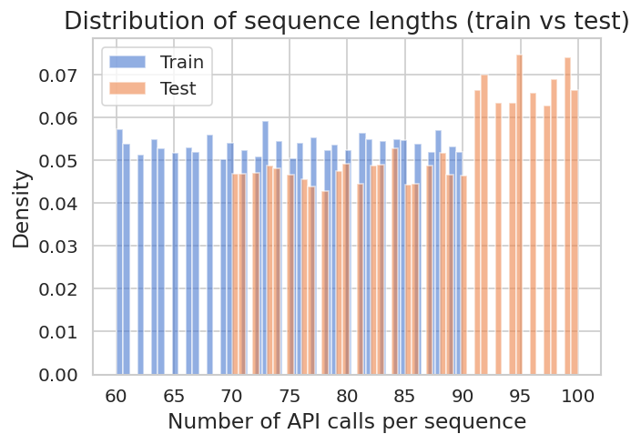

```python
# --- Compare distributions visually ---

fig, ax = plt.subplots(figsize=(6, 4))
ax.hist(df_train['seq_length'], bins=50, alpha=0.6, label='Train', density=True)
ax.hist(df_test['seq_length'], bins=50, alpha=0.6, label='Test', density=True)
ax.set_xlabel("Number of API calls per sequence", fontsize=REPORT_PLOT_LABEL_SIZE)
ax.set_ylabel("Density", fontsize=REPORT_PLOT_LABEL_SIZE)
ax.set_title("Distribution of sequence lengths (train vs test)", fontsize=REPORT_PLOT_TITLE_SIZE)
format_report_axes(ax)

# Save the plot to the specified path
save_plot(fig, f"distribution_sequence_lengths_train_test", save_dir)

plt.show()
```

#### Q: Do you have the same number of API calls per sequence? If not, is the distribution of API calls per sequence the same for training and test sets?

No, the sequences **do not all have the same length** in either the training or test sets.

- **Training set**: sequence lengths range from 60 to 90 API calls (mean ≈ 75).
- **Test set**: sequence lengths range from 70 to 100 API calls (mean ≈ 86).

The **sequences in the test set** are not only longer on average, but also fall within a range (90–100) that is completely absent from the training set. This discrepancy means that the model will have to generalize to sequence lengths it has never encountered during training, posing an additional challenge for sequential architectures.

#### Q: Can a FFNN handle a variable number of elements? If not, why?

No, a feedforward neural network (FFNN) **cannot directly handle a variable number** of elements per input.

- FFNNs require a **fixed-size input vector**, because each input neuron corresponds to a specific feature, and the weight matrix has a fixed shape.
- If the number of elements (features) changes between samples, the network **cannot align inputs with the learned weights**, so it won't work properly.

Due to this architectural constraint, in order to process variable-length API sequences using a FFNN, they must be converted into fixed-length vectors using padding (to extend short sequences) or truncation (to shorten longer ones).

### Fixed-Size Sequences

#### Q: How to estimate a fixed-size candidate? Which partition do you use to estimate it?

To estimate a fixed-size input for an FFNN, it's possible to choose a representative sequence length from the training set only, since the model should not use information from the test set.

Common strategies include:

1. **Maximum length**: ensures all training sequences fit, but can be too large and waste memory.
2. **Median length**: gives a typical sequence size, but some longer sequences will need truncation.
3. **75th percentile length**: a compromise that covers most sequences without being overly large.

Among these strategies, we opted for the maximum training set length (90). This choice is justified by the fact that the distribution of lengths (as seen earlier) is fairly uniform and does not contain any extreme outliers; therefore, the computational “cost” of using 90 as a fixed size is offset by the advantage of not having to truncate (and thus lose) information in any training sequence.

```python
# Compute sequence lengths in training set
seq_lengths = df_train['api_call_sequence'].apply(len)

# Option 1: maximum length
max_len = seq_lengths.max()
print(f"Max length: {max_len}")

# Option 2: median
median_len = int(seq_lengths.median())
print(f"Median length: {median_len}")

# Option 3: 75th percentile
p75_len = int(np.percentile(seq_lengths, 75))
print(f"75th percentile length: {p75_len}")
```

```
Max length: 90
Median length: 75
75th percentile length: 83
```

#### Q: Given the estimate, what technique could you use to obtain the same number of API calls per sequence?

To obtain the same number of API calls per sequence, the main strategies are:

1. **Padding**: Add "dummy" or special tokens to sequences **shorter than the fixed length** so they reach the target size.
2. **Truncation**: **Cut sequences longer than the fixed length** to fit the target size.

By combining padding and truncation based on the estimated fixed length, you can ensure that **all sequences have the same number of elements**, which is required for an FFNN.

```python
def pad_truncate_sequence(seq, fixed_len, pad_value=0):
    """
    Convert a variable-length sequence into a fixed-length sequence.

    Args:
        seq (list): original sequence (list of API calls)
        fixed_len (int): target length L
        pad_value: value to use for padding (0 is common for integers)

    Returns:
        list of length fixed_len
    """
    if len(seq) < fixed_len:
        # Pad at the end
        seq_padded = seq + [pad_value] * (fixed_len - len(seq))
    else:
        # Truncate at the end
        seq_padded = seq[:fixed_len]
    return seq_padded
```

```python
# --- Perform padding or truncating on the training data ---

L = max_len # chosen fixed size

# Apply the padding or truncating to all the dataframe
df_train['seq_fixed'] = df_train['api_call_sequence'].apply(lambda x: pad_truncate_sequence(x, L))
```

```python
# --- Inspect the train set (e.g. the first row) ---

print("First row of the train set before padding:")
print(df_train['api_call_sequence'].iloc[0])
print(f"Lenght of the sequence: {len(df_train['api_call_sequence'].iloc[0])}") # should be less than L

print("\nFirst row of the train set after padding:")
print(df_train['seq_fixed'].iloc[0])
print(f"Lenght of the sequence: {len(df_train['seq_fixed'].iloc[0])}") # should be exactly L
```

```
First row of the train set before padding:
['LdrGetDllHandle', 'LdrGetProcedureAddress', 'LdrLoadDll', 'LdrGetProcedureAddress', 'LdrGetDllHandle', 'LdrGetProcedureAddress', 'GetTimeZoneInformation', 'LoadStringW', 'RegOpenKeyExW', 'RegQueryValueExW', 'RegCloseKey', 'LdrGetDllHandle', 'LdrGetProcedureAddress', 'LdrGetDllHandle', 'LdrGetProce…
Lenght of the sequence: 73

First row of the train set after padding:
['LdrGetDllHandle', 'LdrGetProcedureAddress', 'LdrLoadDll', 'LdrGetProcedureAddress', 'LdrGetDllHandle', 'LdrGetProcedureAddress', 'GetTimeZoneInformation', 'LoadStringW', 'RegOpenKeyExW', 'RegQueryValueExW', 'RegCloseKey', 'LdrGetDllHandle', 'LdrGetProcedureAddress', 'LdrGetDllHandle', 'LdrGetProce…
Lenght of the sequence: 90
```

#### Q: If at test time you have more API calls than the fixed-size, what do you do with the exceeding API calls?

At test time, if a sequence has **more API calls than the fixed size**, the exceeding API calls should be **truncated** to fit the fixed length. **Sequences shorter** than the fixed size are **padded** with dummy tokens.

We have decided to perform the same pad or truncate action on the test set, so that all sequences have a consistent length compatible with the FFNN.

```python
# To ensure consistency, we apply the padding or truncating to also on the test df
df_test['seq_fixed'] = df_test['api_call_sequence'].apply(lambda x: pad_truncate_sequence(x, L))
```

```python
df_train
```

|  | api_call_sequence | is_malware | seq_length | seq_fixed |
| --- | --- | --- | --- | --- |
| 0 | [LdrGetDllHandle, LdrGetProcedureAddress, LdrL... | 1 | 73 | [LdrGetDllHandle, LdrGetProcedureAddress, LdrL... |
| 1 | [NtAllocateVirtualMemory, LdrLoadDll, LdrGetPr... | 1 | 88 | [NtAllocateVirtualMemory, LdrLoadDll, LdrGetPr... |
| 2 | [FindResourceExW, LoadResource, FindResourceEx... | 1 | 79 | [FindResourceExW, LoadResource, FindResourceEx... |
| 3 | [FindResourceExW, LoadResource, FindResourceEx... | 1 | 71 | [FindResourceExW, LoadResource, FindResourceEx... |
| 4 | [LdrGetProcedureAddress, SetErrorMode, LdrLoad... | 1 | 63 | [LdrGetProcedureAddress, SetErrorMode, LdrLoad... |
| ... | ... | ... | ... | ... |
| 16320 | [LdrGetProcedureAddress, LdrLoadDll, LdrGetPro... | 1 | 64 | [LdrGetProcedureAddress, LdrLoadDll, LdrGetPro... |
| 16321 | [NtClose, LdrGetProcedureAddress, CryptCreateH... | 1 | 78 | [NtClose, LdrGetProcedureAddress, CryptCreateH... |
| 16322 | [LdrGetProcedureAddress, LdrGetDllHandle, LdrG... | 1 | 84 | [LdrGetProcedureAddress, LdrGetDllHandle, LdrG... |
| 16323 | [LdrGetProcedureAddress, LdrGetDllHandle, LdrG... | 1 | 62 | [LdrGetProcedureAddress, LdrGetDllHandle, LdrG... |
| 16324 | [SetFilePointer, NtReadFile, SetFilePointer, N... | 1 | 77 | [SetFilePointer, NtReadFile, SetFilePointer, N... |

16325 rows × 4 columns

```python
df_test
```

|  | api_call_sequence | is_malware | seq_length | seq_fixed |
| --- | --- | --- | --- | --- |
| 0 | [NtQueryValueKey, NtClose, NtOpenKey, NtQueryV... | 1 | 98 | [NtQueryValueKey, NtClose, NtOpenKey, NtQueryV... |
| 1 | [LdrGetProcedureAddress, NtClose, NtOpenKey, N... | 1 | 98 | [LdrGetProcedureAddress, NtClose, NtOpenKey, N... |
| 2 | [NtOpenKey, NtQueryValueKey, NtClose, NtOpenKe... | 1 | 99 | [NtOpenKey, NtQueryValueKey, NtClose, NtOpenKe... |
| 3 | [NtAllocateVirtualMemory, LdrLoadDll, LdrGetPr... | 1 | 85 | [NtAllocateVirtualMemory, LdrLoadDll, LdrGetPr... |
| 4 | [NtOpenKey, NtQueryValueKey, NtClose, LdrGetPr... | 1 | 80 | [NtOpenKey, NtQueryValueKey, NtClose, LdrGetPr... |
| ... | ... | ... | ... | ... |
| 6500 | [SetErrorMode, NtOpenFile, NtClose, SHGetFolde... | 0 | 75 | [SetErrorMode, NtOpenFile, NtClose, SHGetFolde... |
| 6501 | [NtProtectVirtualMemory, RegOpenKeyExW, RegQue... | 1 | 83 | [NtProtectVirtualMemory, RegOpenKeyExW, RegQue... |
| 6502 | [RegOpenKeyExW, RegQueryValueExW, RegCloseKey,... | 1 | 70 | [RegOpenKeyExW, RegQueryValueExW, RegCloseKey,... |
| 6503 | [NtQueryValueKey, NtClose, RegOpenKeyExA, RegQ... | 1 | 96 | [NtQueryValueKey, NtClose, RegOpenKeyExA, RegQ... |
| 6504 | [NtClose, LdrGetProcedureAddress, CryptCreateH... | 1 | 78 | [NtClose, LdrGetProcedureAddress, CryptCreateH... |

6505 rows × 4 columns

### Handling Categorical Features

```python
# --- Build a unified vocabulary ---

all_sequences = df_train['seq_fixed']

# Flatten all sequences into a single list of API calls
all_api_calls = [api for seq in all_sequences for api in seq]
```

```python
# --- Build vocabulary with padding handling ---

# 1. Filter strings only. We ignore 0 here because we will manually assign it later.
unique_api_calls = sorted(list(set(api for api in all_api_calls if isinstance(api, str))))

# 2. Define Special Tokens
PAD_IDX = 0  # <PAD>
UNK_IDX = 1  # <UNK>

# 3. Map API call -> sequential ID (Start from 2 to save space for PAD and UNK)
api_to_id = {api: i + 2 for i, api in enumerate(unique_api_calls)}

# 4. Add the special tokens to the dictionary
# (Optional: helpful if you need to reverse look up '<PAD>' later)
api_to_id['<PAD>'] = PAD_IDX
api_to_id['<UNK>'] = UNK_IDX

# Map sequential ID -> API call (for verification/debugging)
id_to_api = {i: api for api, i in api_to_id.items()}

print(f"Number of unique API calls (including special tokens): {len(api_to_id)}")
print("\nExample mapping (API -> ID):", list(api_to_id.items())[:5])
print("\nExample mapping (ID -> API):", list(id_to_api.items())[:5])
```

```
Number of unique API calls (including special tokens): 260

Example mapping (API -> ID): [('CertOpenStore', 2), ('CertOpenSystemStoreW', 3), ('CoCreateInstance', 4), ('CoCreateInstanceEx', 5), ('CoGetClassObject', 6)]

Example mapping (ID -> API): [(2, 'CertOpenStore'), (3, 'CertOpenSystemStoreW'), (4, 'CoCreateInstance'), (5, 'CoCreateInstanceEx'), (6, 'CoGetClassObject')]
```

#### Sequential Identifiers Approach

```python
def sequence_to_ids(seq, mapping, pad_idx, unk_idx):
    """
    Convert a sequence of API calls to their corresponding IDs.
    - If item is 0 (integer padding), map to pad_idx.
    - If item is string but not in mapping, map to unk_idx.
    """
    ids = []
    for item in seq:
        # Case A: It is existing padding (integer 0)
        if item == 0:
            ids.append(pad_idx)
        # Case B: It is a known string API
        elif item in mapping:
            ids.append(mapping[item])
        # Case C: It is an unknown string API (Test set OOV)
        else:
            ids.append(unk_idx)
    return ids
```

```python
# --- Convert sequences to sequential IDs ---

# Apply conversion to train and test sets
# Note: We pass UNK_IDX (1) so unknown calls in Test set become 1.
df_train['seq_sequential_ids'] = df_train['seq_fixed'].apply(
    lambda seq: sequence_to_ids(seq, api_to_id, PAD_IDX, UNK_IDX)
)

df_test['seq_sequential_ids'] = df_test['seq_fixed'].apply(
    lambda seq: sequence_to_ids(seq, api_to_id, PAD_IDX, UNK_IDX)
)

# Quick check
print("\nSequential IDs - first row of train set:")
print(df_train['seq_sequential_ids'].iloc[0])
print("Length of the sequence:", len(df_train['seq_sequential_ids'].iloc[0]))

print("\nSequential IDs - first row of test set:")
print(df_test['seq_sequential_ids'].iloc[0])
print("Length of the sequence:", len(df_test['seq_sequential_ids'].iloc[0]))

# Verify that the logic works (check for any None values)
# If this prints nothing, your data is clean!
for seq in df_test['seq_sequential_ids']:
    if None in seq:
        print("Error: Found None in sequence! Check mapping.")
        break
```

```
Sequential IDs - first row of train set:
[117, 118, 119, 118, 117, 118, 86, 123, 201, 205, 188, 117, 118, 117, 118, 219, 119, 219, 119, 219, 81, 46, 179, 46, 121, 46, 121, 134, 133, 81, 133, 119, 118, 119, 118, 119, 118, 119, 118, 119, 118, 124, 118, 124, 119, 118, 119, 118, 119, 118, 117, 46, 121, 46, 121, 39, 81, 46, 121, 81, 39, 117, 46…
Length of the sequence: 90

Sequential IDs - first row of test set:
[164, 134, 152, 164, 134, 159, 122, 133, 122, 117, 118, 117, 118, 117, 122, 118, 81, 46, 121, 46, 121, 46, 121, 46, 121, 46, 121, 46, 121, 46, 121, 46, 121, 46, 121, 46, 121, 46, 121, 46, 121, 46, 121, 46, 121, 118, 46, 121, 46, 121, 133, 81, 134, 81, 133, 119, 118, 117, 46, 121, 46, 121, 39, 81, 46…
Length of the sequence: 90
```

```python
df_train
```

|  | api_call_sequence | is_malware | seq_length | seq_fixed | seq_sequential_ids |
| --- | --- | --- | --- | --- | --- |
| 0 | [LdrGetDllHandle, LdrGetProcedureAddress, LdrL... | 1 | 73 | [LdrGetDllHandle, LdrGetProcedureAddress, LdrL... | [117, 118, 119, 118, 117, 118, 86, 123, 201, 2... |
| 1 | [NtAllocateVirtualMemory, LdrLoadDll, LdrGetPr... | 1 | 88 | [NtAllocateVirtualMemory, LdrLoadDll, LdrGetPr... | [133, 119, 118, 82, 80, 137, 82, 152, 153, 163... |
| 2 | [FindResourceExW, LoadResource, FindResourceEx... | 1 | 79 | [FindResourceExW, LoadResource, FindResourceEx... | [46, 121, 46, 121, 46, 121, 46, 121, 46, 121, ... |
| 3 | [FindResourceExW, LoadResource, FindResourceEx... | 1 | 71 | [FindResourceExW, LoadResource, FindResourceEx... | [46, 121, 46, 121, 46, 121, 46, 121, 46, 121, ... |
| 4 | [LdrGetProcedureAddress, SetErrorMode, LdrLoad... | 1 | 63 | [LdrGetProcedureAddress, SetErrorMode, LdrLoad... | [118, 219, 119, 219, 81, 46, 121, 46, 121, 46,... |
| ... | ... | ... | ... | ... | ... |
| 16320 | [LdrGetProcedureAddress, LdrLoadDll, LdrGetPro... | 1 | 64 | [LdrGetProcedureAddress, LdrLoadDll, LdrGetPro... | [118, 119, 118, 119, 118, 119, 118, 119, 118, ... |
| 16321 | [NtClose, LdrGetProcedureAddress, CryptCreateH... | 1 | 78 | [NtClose, LdrGetProcedureAddress, CryptCreateH... | [134, 118, 24, 118, 30, 118, 135, 66, 221, 166... |
| 16322 | [LdrGetProcedureAddress, LdrGetDllHandle, LdrG... | 1 | 84 | [LdrGetProcedureAddress, LdrGetDllHandle, LdrG... | [118, 117, 118, 81, 216, 119, 118, 46, 121, 46... |
| 16323 | [LdrGetProcedureAddress, LdrGetDllHandle, LdrG... | 1 | 62 | [LdrGetProcedureAddress, LdrGetDllHandle, LdrG... | [118, 117, 118, 117, 118, 117, 118, 117, 118, ... |
| 16324 | [SetFilePointer, NtReadFile, SetFilePointer, N... | 1 | 77 | [SetFilePointer, NtReadFile, SetFilePointer, N... | [221, 166, 221, 166, 221, 45, 121, 133, 146, 1... |

16325 rows × 5 columns

```python
df_test
```

|  | api_call_sequence | is_malware | seq_length | seq_fixed | seq_sequential_ids |
| --- | --- | --- | --- | --- | --- |
| 0 | [NtQueryValueKey, NtClose, NtOpenKey, NtQueryV... | 1 | 98 | [NtQueryValueKey, NtClose, NtOpenKey, NtQueryV... | [164, 134, 152, 164, 134, 159, 122, 133, 122, ... |
| 1 | [LdrGetProcedureAddress, NtClose, NtOpenKey, N... | 1 | 98 | [LdrGetProcedureAddress, NtClose, NtOpenKey, N... | [118, 134, 152, 164, 134, 152, 164, 134, 119, ... |
| 2 | [NtOpenKey, NtQueryValueKey, NtClose, NtOpenKe... | 1 | 99 | [NtOpenKey, NtQueryValueKey, NtClose, NtOpenKe... | [152, 164, 134, 152, 164, 134, 117, 118, 117, ... |
| 3 | [NtAllocateVirtualMemory, LdrLoadDll, LdrGetPr... | 1 | 85 | [NtAllocateVirtualMemory, LdrLoadDll, LdrGetPr... | [133, 119, 118, 119, 118, 82, 200, 204, 188, 1... |
| 4 | [NtOpenKey, NtQueryValueKey, NtClose, LdrGetPr... | 1 | 80 | [NtOpenKey, NtQueryValueKey, NtClose, LdrGetPr... | [152, 164, 134, 118, 24, 118, 30, 118, 135, 66... |
| ... | ... | ... | ... | ... | ... |
| 6500 | [SetErrorMode, NtOpenFile, NtClose, SHGetFolde... | 0 | 75 | [SetErrorMode, NtOpenFile, NtClose, SHGetFolde... | [219, 151, 134, 214, 219, 63, 219, 151, 134, 1... |
| 6501 | [NtProtectVirtualMemory, RegOpenKeyExW, RegQue... | 1 | 83 | [NtProtectVirtualMemory, RegOpenKeyExW, RegQue... | [158, 201, 205, 188, 140, 133, 158, 133, 146, ... |
| 6502 | [RegOpenKeyExW, RegQueryValueExW, RegCloseKey,... | 1 | 70 | [RegOpenKeyExW, RegQueryValueExW, RegCloseKey,... | [201, 205, 188, 201, 205, 188, 80, 117, 118, 2... |
| 6503 | [NtQueryValueKey, NtClose, RegOpenKeyExA, RegQ... | 1 | 96 | [NtQueryValueKey, NtClose, RegOpenKeyExA, RegQ... | [164, 134, 200, 204, 188, 153, 164, 134, 119, ... |
| 6504 | [NtClose, LdrGetProcedureAddress, CryptCreateH... | 1 | 78 | [NtClose, LdrGetProcedureAddress, CryptCreateH... | [134, 118, 24, 118, 30, 118, 135, 66, 221, 166... |

6505 rows × 5 columns

#### Learnable Embeddings Approach

```python
# The learnable embeddings approach is implemented in the first layer of the neural network model.
# The nn.Embedding layer in the MalwareFFNN class handles this process.
```

### FFNN Training

```python
class MalwareFFNN(nn.Module):
    def __init__(self, seq_len, hidden_dims=[128,64,32],
                 dropout_rates=None, batchnorm_flags=None,
                 use_embedding=True, vocab_size=None, embedding_dim=16,
                 dropout_embedding_rate=0.1):
        """
        Flexible FFNN for malware classification.

        Parameters:
        - seq_len: length of each API call sequence
        - vocab_size: number of unique API calls (required if use_embedding=True)
        - hidden_dims: list of hidden layer sizes
        - embedding_dim: size of embedding vectors (only used if use_embedding=True)
        - use_embedding: whether to use an embedding layer (True) or raw sequential IDs / one-hot (False)
        """
        super(MalwareFFNN, self).__init__()
        self.use_embedding = use_embedding

        if self.use_embedding:
            if vocab_size is None:
                raise ValueError("vocab_size must be provided if use_embedding=True")

            # Embedding layer for sequential IDs
            self.embedding = nn.Embedding(num_embeddings=vocab_size, embedding_dim=embedding_dim, padding_idx=0)
            input_dim = seq_len * embedding_dim

            self.dropout_embed = nn.Dropout(dropout_embedding_rate)
        else:
            # Input will be one-hot encoded or numeric vector
            input_dim = seq_len # assumes IDs are already numeric

        # Ensure defaults if none are provided
        if dropout_rates is None:
            dropout_rates = [0.0] * len(hidden_dims)     # no dropout by default
        if batchnorm_flags is None:
            batchnorm_flags = [False] * len(hidden_dims) # no batchnorm by default

        # Safety check for lengths
        assert len(dropout_rates) == len(hidden_dims), \
            "dropout_rates length must match hidden_dims length"
        assert len(batchnorm_flags) == len(hidden_dims), \
            "batchnorm_flags length must match hidden_dims length"

        # Build hidden layers
        layers = []
        prev_dim = input_dim
        for h_dim, dropout_rate, use_bn in zip(hidden_dims, dropout_rates, batchnorm_flags):
            layers.append(nn.Linear(prev_dim, h_dim))
            if use_bn:
                layers.append(nn.BatchNorm1d(h_dim))
            layers.append(nn.ReLU())
            if dropout_rate > 0:
                layers.append(nn.Dropout(dropout_rate))
            prev_dim = h_dim
        self.ffnn = nn.Sequential(*layers)

        # Output layer: binary classification
        self.output_layer = nn.Linear(prev_dim, 1)

    def forward(self, x):
        if self.use_embedding:
            # x: [batch_size, seq_len] of IDs
            x = self.embedding(x)     # [batch_size, seq_len, embedding_dim]
            x = self.dropout_embed(x)
            x = x.view(x.size(0), -1) # flatten: [batch_size, seq_len*embedding_dim]
        else:
            # x: [batch_size, seq_len] or [batch_size, seq_len*vocab_size] if one-hot flattened
            x = x.float()

        x = self.ffnn(x)
        out = self.output_layer(x) # [batch_size, 1]
        return out
```

```python
# --- Training function with early stopping ---

def train_model(model, train_loader, val_loader, epochs, optimizer, criterion, min_delta=None, patience=None, scheduler=None):
    """
    Train a PyTorch model with early stopping and metric tracking.
    Returns: model, history dictionary (losses + metrics), and elapsed time.
    """

    # --- DEVICE DETECTION ---
    device = next(model.parameters()).device

    # --- HISTORY STORAGE ---
    history = {
        'train_loss': [],
        'val_loss': [],
        'val_f1_macro': [],
        'val_f1_weighted': [],
    }

    best_val_loss = float('inf')
    best_model_state = None
    trigger_times = 0

    start_time = time.time()

    for epoch in range(epochs):
        # --- TRAINING ---
        model.train()
        batch_losses = []
        for X_batch, y_batch in train_loader:
            X_batch, y_batch = X_batch.to(device), y_batch.to(device)
            optimizer.zero_grad()
            outputs = model(X_batch)
            loss = criterion(outputs, y_batch)
            loss.backward()
            optimizer.step()
            batch_losses.append(loss.item())
        train_loss = np.mean(batch_losses) if batch_losses else 0.0

        # --- VALIDATION & METRICS ---
        model.eval()
        val_batch_losses = []
        all_preds = []
        all_targets = []

        with torch.no_grad():
            for X_batch, y_batch in val_loader:
                X_batch, y_batch = X_batch.to(device), y_batch.to(device)
                outputs = model(X_batch)
                loss = criterion(outputs, y_batch)
                val_batch_losses.append(loss.item())

                # Convert logits to probabilities and then binary predictions (0 or 1)
                # Assumes Binary Classification (BCEWithLogitsLoss)
                probs = torch.sigmoid(outputs)
                preds = (probs > 0.5).float()

                # Store for epoch-level metric calculation
                all_preds.extend(preds.cpu().numpy())
                all_targets.extend(y_batch.cpu().numpy())

        val_loss = np.mean(val_batch_losses) if val_batch_losses else 0.0

        # Calculate Metrics for this Epoch
        epoch_f1_macro = f1_score(all_targets, all_preds, average='macro', zero_division=0)
        epoch_f1_weighted = f1_score(all_targets, all_preds, average='weighted', zero_division=0)

        # Update History
        history['train_loss'].append(train_loss)
        history['val_loss'].append(val_loss)
        history['val_f1_macro'].append(epoch_f1_macro)
        history['val_f1_weighted'].append(epoch_f1_weighted)

        # --- SCHEDULER STEP ---
        if scheduler is not None:
            last_lr = optimizer.param_groups[0]['lr']
            if isinstance(scheduler, torch.optim.lr_scheduler.ReduceLROnPlateau):
                scheduler.step(val_loss)
            else:
                scheduler.step()
            curr_lr = optimizer.param_groups[0]['lr']
            if curr_lr != last_lr:
                print(f"Epoch {epoch}: LR reduced from {last_lr:.6f} to {curr_lr:.6f}")

        # --- EARLY STOPPING ---
        if min_delta is not None:
            if val_loss < best_val_loss - min_delta:
                best_val_loss = val_loss
                # Save best model state
                best_model_state = {k: v.cpu().clone() for k, v in model.state_dict().items()}
                trigger_times = 0
            else:
                trigger_times += 1
                if trigger_times >= patience:
                    print(f"Early stopping at epoch {epoch+1} (best val loss: {best_val_loss:.6f})")
                    break

        if (epoch+1) % 5 == 0 or epoch == 0 or epoch == epochs:
            print(f"Epoch {epoch+1}/{epochs} - Train Loss: {train_loss:.4f}, Val Loss: {val_loss:.4f}, Val F1(W): {epoch_f1_weighted:.4f}")

    # Restore best model after training loop completes
    if best_model_state is not None:
        model.load_state_dict(best_model_state)
        model.to(device)

    elapsed = time.time() - start_time
    elapsed_str = time.strftime('%H:%M:%S', time.gmtime(elapsed))
    print(f'\nTraining completed in {elapsed_str} (hh:mm:ss) — {elapsed:.2f} seconds')

    return model, history, elapsed
```

```python
def evaluate_model(model, X_tensor, y_true, model_name: str = "Unnamed model"):
    """
    Evaluate a trained model on a given dataset and return the classification report.

    Handles missing predicted classes gracefully (zero_division=0) and
    reports which classes were not predicted, along with the model/config name.
    """
    model.eval()
    with torch.no_grad():
        outputs = model(X_tensor)
        probs = torch.sigmoid(outputs)
        y_pred = (probs > 0.5).long().cpu().numpy().flatten() # Binary prediction (0 or 1)

    # Convert y_true to numpy if it's a tensor
    if isinstance(y_true, torch.Tensor):
        y_true = y_true.cpu().numpy().flatten()

    # Identify missing classes (not predicted at all)
    missing_classes = set(np.unique(y_true)) - set(np.unique(y_pred))
    if missing_classes:
        missing_classes = [int(x) for x in sorted(missing_classes)]
        print(f"Warning: {model_name} made no predictions for classes: {missing_classes}")

    # Generate classification report without raising warnings
    report = classification_report(y_true, y_pred, digits=4, zero_division=0)

    return report
```

```python
def plot_cm_task2(model, X_tensor, y_tensor, model_name, save_dir=None):
    """
    Specific for FFNN. Takes tensors, moves to device, predicts, and plots.
    """
    # Ensure model is in eval mode
    model.eval()

    # Detect device (cuda or cpu) from the model parameters
    device = next(model.parameters()).device

    # Move inputs to the same device as model
    X_input = X_tensor.to(device)

    with torch.no_grad():
        # Get logits
        outputs = model(X_input)
        # Apply sigmoid to get probabilities
        probs = torch.sigmoid(outputs)
        # Convert to binary predictions (0 or 1)
        y_pred = (probs > 0.5).long().cpu().numpy().flatten()

    # Ensure y_true is on CPU and numpy
    y_true = y_tensor.cpu().numpy().flatten()

    # Plot
    _internal_plot_cm(y_true, y_pred, model_name, save_dir)
```

```python
def plot_training_metrics(histories, model_names=None, save_dir=None, plot_name="validation_f1_macro_comparison"):
      """
      Compare multiple models' validation F1 Macro across epochs.
      Only shows validation F1 macro (no weighted, no markers for cleaner plots).
      """
      # Normalize input
      if isinstance(histories, dict):
          hist_map = histories
          names = [f"lr_{k:.0e}" if isinstance(k, float) else str(k) for k in hist_map.keys()]
          hist_map = dict(zip(names, hist_map.values()))
      else:
          if model_names is None:
              names = [f"Model_{i+1}" for i in range(len(histories))]
          else:
              names = list(model_names)
          hist_map = dict(zip(names, histories))

      # Validate
      for name, h in hist_map.items():
          if 'val_f1_macro' not in h:
              raise KeyError(f"History for '{name}' must contain 'val_f1_macro'.")

      colors = ['#E74C3C', '#F39C12', '#27AE60', '#3498DB', '#9B59B6', '#34495E']

      fig, ax = plt.subplots(figsize=(10, 5))

      for idx, (name, h) in enumerate(hist_map.items()):
          epochs = range(1, len(h['val_f1_macro']) + 1)
          color = colors[idx % len(colors)]
          ax.plot(epochs, h['val_f1_macro'], label=name, linewidth=REPORT_PLOT_LINEWIDTH, color=color)

      ax.set_title("Validation F1 Macro Comparison", fontsize=REPORT_PLOT_TITLE_SIZE)
      ax.set_xlabel("Epochs", fontsize=REPORT_PLOT_LABEL_SIZE)
      ax.set_ylabel("F1 Macro", fontsize=REPORT_PLOT_LABEL_SIZE)
      ax.grid(True, alpha=0.3)
      format_report_axes(ax)
      plt.tight_layout()

      if save_dir:
            save_plot(fig, filename=plot_name, path=save_dir, fmt="png", dpi=300, close_fig=False)
      plt.show()
```

```python
# --- Plotting function for LR comparison ---
def plot_lr_comparison(histories_dict, model_name, save_dir=None):
      """
      Plot ONLY validation losses for different learning rates.
      (When multiple LRs are present, we show only val curves for readability.)
      """
      plt.style.use('seaborn-v0_8-paper')

      fig, ax = plt.subplots(figsize=(8, 5))

      colors = ['#E74C3C', '#F39C12', '#27AE60', '#3498DB', '#9B59B6', '#34495E']

      for idx, (lr, history) in enumerate(sorted(histories_dict.items(), reverse=True)):
          color = colors[idx % len(colors)]
          label = f'lr_{lr:.0e}'
          ax.plot(history['val_loss'], color=color, linewidth=REPORT_PLOT_LINEWIDTH, label=label, alpha=0.8)

      ax.set_title(f'{model_name} — Validation Loss (LR Comparison)', fontsize=REPORT_PLOT_TITLE_SIZE, pad=10)
      ax.set_ylabel('Validation Loss', fontsize=REPORT_PLOT_LABEL_SIZE)
      ax.set_xlabel('Epochs', fontsize=REPORT_PLOT_LABEL_SIZE)
      ax.grid(True, linestyle='-', alpha=0.3)
      ax.spines['top'].set_visible(False)
      ax.spines['right'].set_visible(False)
      format_report_axes(ax)

      plt.tight_layout()

      if save_dir:
          save_plot(fig, f'{model_name.lower().replace(" ", "_")}_lr_comparison', save_dir)

      plt.show()
```

```python
# --- Plot Train vs Val ---

def plot_train_val_grid(histories_dict, model_name, save_dir=None):
    """
    Plots a grid (1 row, N columns) showing Train vs Val loss for EACH learning rate.
    This helps diagnose overfitting/underfitting for each specific setting.
    Works for both FFNN (Task 2) and RNN (Task 3) models.

    Args:
        histories_dict: Dictionary with LR values as keys and history dicts as values
        model_name: Name of the model architecture
        save_dir: Directory to save the plot
    """
    lrs = sorted(histories_dict.keys(), reverse=True) # Highest LR first
    num_lrs = len(lrs)

    # Set style
    plt.style.use('seaborn-v0_8-paper')

    # Create figure with 1 row and N columns
    fig, axes = plt.subplots(1, num_lrs, figsize=(5 * num_lrs, 4), sharey=True)

    # Handle case if there is only 1 LR (axes is not a list)
    if num_lrs == 1:
        axes = [axes]

    # Common colors
    col_train = '#2980B9' # Blue
    col_val = '#E74C3C'   # Red

    for idx, lr in enumerate(lrs):
        ax = axes[idx]
        history = histories_dict[lr]
        epochs = range(1, len(history['train_loss']) + 1)

        # Plot Lines
        ax.plot(epochs, history['train_loss'], label='Train Loss', color=col_train, linewidth=REPORT_PLOT_LINEWIDTH)
        ax.plot(epochs, history['val_loss'], label='Val Loss', color=col_val, linewidth=REPORT_PLOT_LINEWIDTH)

        # Find best epoch (min val loss)
        min_val_loss = min(history['val_loss'])
        best_epoch = history['val_loss'].index(min_val_loss) + 1

        # Mark best epoch
        ax.axvline(x=best_epoch, color='green', linestyle=':', alpha=0.6, label=f'Best Ep: {best_epoch}')
        ax.scatter(best_epoch, min_val_loss, color='green', zorder=5)

        # Styling
        ax.set_title(f'LR: {lr:.0e}', fontsize=REPORT_PLOT_TITLE_SIZE, fontweight='bold')
        ax.set_xlabel('Epochs', fontsize=REPORT_PLOT_LABEL_SIZE)
        if idx == 0:
            ax.set_ylabel('Loss', fontsize=REPORT_PLOT_LABEL_SIZE)

        format_report_axes(ax)
        ax.grid(True, linestyle='-', alpha=0.3)
        ax.spines['top'].set_visible(False)
        ax.spines['right'].set_visible(False)

    fig.suptitle(f'{model_name} - Overfitting Diagnosis (Train vs Val)', fontsize=REPORT_PLOT_TITLE_SIZE, y=1.05)
    plt.tight_layout()

    if save_dir:
        save_plot(fig, f'{model_name.lower().replace(" ", "_")}_diagnosis', save_dir)

    plt.show()
```

#### Training with Sequential Identifiers Approach

```python
# --- Create a validation set ---

# Convert sequences to a numpy array (shape: [samples, seq_len])
X_train = np.array(df_train['seq_sequential_ids'].tolist())
X_test = np.array(df_test['seq_sequential_ids'].tolist())

# Labels
y_train = df_train['is_malware'].values
y_test = df_test['is_malware'].values

# Split train into train + val
X_train_split, X_val, y_train_split, y_val = train_test_split(
    X_train, y_train, test_size=0.2, random_state=42, stratify=y_train
)

print("Train set:", X_train_split.shape, y_train_split.shape)
print("Validation set:", X_val.shape, y_val.shape)
```

```
Train set: (13060, 90) (13060,)
Validation set: (3265, 90) (3265,)
```

```python
# --- Prepare PyTorch datasets and loaders ---

# Convert to tensors
X_train_tensor = torch.tensor(X_train_split.astype(np.int64), dtype=torch.long)
y_train_tensor = torch.tensor(y_train_split, dtype=torch.float32).unsqueeze(1)

X_val_tensor = torch.tensor(X_val.astype(np.int64), dtype=torch.long)
y_val_tensor = torch.tensor(y_val, dtype=torch.float32).unsqueeze(1)

X_test_tensor = torch.tensor(X_test.astype(np.int64), dtype=torch.long)
y_test_tensor = torch.tensor(y_test, dtype=torch.float32).unsqueeze(1)

# Create datasets and loaders
batch_size = 64

train_dataset = TensorDataset(X_train_tensor, y_train_tensor)
val_dataset = TensorDataset(X_val_tensor, y_val_tensor)
test_dataset = TensorDataset(X_test_tensor, y_test_tensor)

train_loader = DataLoader(train_dataset, batch_size=batch_size, shuffle=True)
val_loader = DataLoader(val_dataset, batch_size=batch_size, shuffle=True)
test_loader = DataLoader(test_dataset, batch_size=batch_size, shuffle=True)
```

```python
unique, counts = np.unique(y_train_split, return_counts=True)
print(dict(zip(unique, counts)))
```

```
{np.int64(0): np.int64(489), np.int64(1): np.int64(12571)}
```

```python
def compute_pos_weight(y):
    """
    Compute positive class weight for BCEWithLogitsLoss.
    Returns a tensor > 1 if positive class is minority.
    """
    y_np = np.array(y, dtype=int)
    class_counts = np.bincount(y_np)

    if len(class_counts) < 2:
        raise ValueError("Dataset must contain both classes 0 and 1.")

    count_neg, count_pos = class_counts[0], class_counts[1]

    # if 1 = malware (majority class)
    ratio = count_neg / count_pos

    # Optionally stabilize the weight
    ratio = max(ratio, 0.2)

    print(f"Negatives: {count_neg}, Positives: {count_pos}")
    print(f"pos_weight (applied to y=1 samples): {ratio:.4f}")

    # return torch.tensor([ratio], dtype=torch.float32)
    return torch.tensor([ratio], dtype=torch.float32)
```

```python
# --- Configuration Constants ---
seq_len = X_train.shape[1]
hidden_dims = [256, 128, 64]
dropout_rates = [0.4, 0.35, 0.3]
batchnorm_flags = [True, True, True]
min_delta = 0.00001
patience_early_stop = 15
epochs = 100

# --- Device Setup ---
device = torch.device('cuda' if torch.cuda.is_available() else 'cpu')
print(f"Using device: {device}")

# Compute weights and move to device
pos_weight = compute_pos_weight(y_train_split).to(device)

# --- Define LR Candidates ---
learning_rates_seq = [0.0001, 0.00005, 0.00001]
histories_seq = {}     # Store results here
models_seq = {}        # Store models here
elapsed_seq_times = {} # Store elapsed times here

print(f"\n{'='*80}")
print("Training FFNN (Sequential IDs) with different learning rates")
print(f"{'='*80}")

for lr in learning_rates_seq:
    print(f"\n--- Training FFNN (Sequential IDs) with lr={lr:.0e} ---")

    # 1. Re-Initialize Model and move to device
    model_seq = MalwareFFNN(
        seq_len,
        hidden_dims,
        dropout_rates,
        batchnorm_flags,
        use_embedding=False,
        dropout_embedding_rate=0.1
    ).to(device)

    # 2. Re-Initialize Criterion
    criterion = nn.BCEWithLogitsLoss(pos_weight=pos_weight)

    # 3. Initialize Optimizer with current LR
    optimizer = optim.AdamW(model_seq.parameters(), lr=lr, weight_decay=1e-5)

    # 4. Initialize Scheduler
    scheduler = torch.optim.lr_scheduler.ReduceLROnPlateau(
        optimizer,
        mode='min',
        factor=0.7,
        patience=10,
        min_lr=1e-6
    )

    # 5. Train
    model_seq, history, elapsed_seq = train_model(
        model_seq,
        train_loader,
        val_loader,
        epochs,
        optimizer,
        criterion,
        min_delta,
        patience=patience_early_stop,
        scheduler=scheduler
    )

    # Store model and history with numeric LR key
    models_seq[lr] = model_seq
    histories_seq[lr] = history
    elapsed_seq_times[lr] = elapsed_seq

    elapsed_str = time.strftime('%H:%M:%S', time.gmtime(elapsed_seq))
    print(f"Completed. Training time: {elapsed_str} ({elapsed_seq:.2f}s) - Final val loss: {history['val_loss'][-1]:.4f}")
```

```
Using device: cuda
Negatives: 489, Positives: 12571
pos_weight (applied to y=1 samples): 0.2000

================================================================================
Training FFNN (Sequential IDs) with different learning rates
================================================================================

--- Training FFNN (Sequential IDs) with lr=1e-04 ---
Epoch 35: LR reduced from 0.000100 to 0.000070
Early stopping at epoch 40 (best val loss: 0.092065)

Training completed in 00:00:32 (hh:mm:ss) — 32.39 seconds
Completed. Training time: 00:00:32 (32.39s) - Final val loss: 0.0960

--- Training FFNN (Sequential IDs) with lr=5e-05 ---
Epoch 46: LR reduced from 0.000050 to 0.000035
Early stopping at epoch 51 (best val loss: 0.094783)

Training completed in 00:00:44 (hh:mm:ss) — 44.37 seconds
Completed. Training time: 00:00:44 (44.37s) - Final val loss: 0.0966

--- Training FFNN (Sequential IDs) with lr=1e-05 ---
Epoch 87: LR reduced from 0.000010 to 0.000007

Training completed in 00:01:21 (hh:mm:ss) — 81.54 seconds
Completed. Training time: 00:01:21 (81.54s) - Final val loss: 0.0977
```

```
Saved plot: /content/drive/MyDrive/Projects/AImSecure/Laboratory2/results/images/task2_plots/ffnn_sequential_ids_lr_comparison.png
```

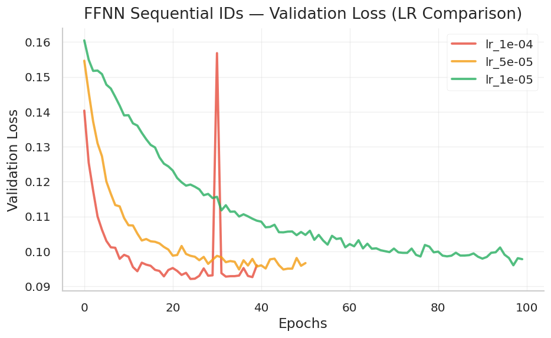

```
Saved plot: /content/drive/MyDrive/Projects/AImSecure/Laboratory2/results/images/task2_plots/ffnn_sequential_ids_diagnosis.png
```

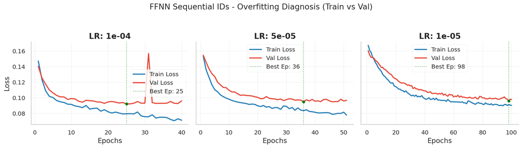

```python
# --- Plot loss curves ---

# Plot comparison
plot_lr_comparison(histories_seq, "FFNN Sequential IDs", save_dir)

# Plot Train vs Validation
plot_train_val_grid(histories_seq, "FFNN Sequential IDs", save_dir)
```

```python
# --- Evaluate validation and test sets for ALL learning rates ---

print("\n" + "=" * 80)
print("Evaluation for ALL FFNN (Sequential IDs) learning rates")
print("=" * 80)

for lr in learning_rates_seq:
    model = models_seq[lr]

    print(f"\n{'='*60}")
    print(f"FFNN (Sequential IDs) with lr={lr:.0e}")
    print(f"{'='*60}")

    # Validation evaluation
    print(f'\nValidation report (FFNN Sequential IDs - lr={lr:.0e}):')
    report = evaluate_model(model, X_val_tensor.to(device), y_val) # Moved X_val_tensor to device
    print(report)

    # Test evaluation
    print(f'Test report (FFNN Sequential IDs - lr={lr:.0e}):')
    report_test = evaluate_model(model, X_test_tensor.to(device), y_test) # Moved X_test_tensor to device
    print(report_test)

# Find and highlight best model
best_lr_seq = min(histories_seq.items(), key=lambda x: min(x[1]['val_loss']))
print(f"\n{'='*60}")
print(f"✓ Best FFNN (Sequential IDs) - LR: {best_lr_seq[0]:.0e} (Min Val Loss: {min(best_lr_seq[1]['val_loss']):.4f})")
print(f"{'='*60}")
```

```
================================================================================
Evaluation for ALL FFNN (Sequential IDs) learning rates
================================================================================

============================================================
FFNN (Sequential IDs) with lr=1e-04
============================================================

Validation report (FFNN Sequential IDs - lr=1e-04):
              precision    recall  f1-score   support

           0     0.1034    0.1475    0.1216       122
           1     0.9664    0.9504    0.9583      3143

    accuracy                         0.9204      3265
   macro avg     0.5349    0.5490    0.5400      3265
weighted avg     0.9341    0.9204    0.9270      3265

Test report (FFNN Sequential IDs - lr=1e-04):
              precision    recall  f1-score   support

           0     0.1225    0.1276    0.1250       243
           1     0.9661    0.9645    0.9653      6262

    accuracy                         0.9333      6505
   macro avg     0.5443    0.5461    0.5452      6505
weighted avg     0.9346    0.9333    0.9339      6505


============================================================
FFNN (Sequential IDs) with lr=5e-05
============================================================

Validation report (FFNN Sequential IDs - lr=5e-05):
              precision    recall  f1-score   support

           0     0.1124    0.1639    0.1333       122
           1     0.9670    0.9497    0.9583      3143

    accuracy                         0.9204      3265
```

[output cut: 27 more lines]

```

Test report (FFNN Sequential IDs - lr=1e-05):
              precision    recall  f1-score   support

           0     0.1600    0.0329    0.0546       243
           1     0.9636    0.9933    0.9782      6262

    accuracy                         0.9574      6505
   macro avg     0.5618    0.5131    0.5164      6505
weighted avg     0.9336    0.9574    0.9437      6505


============================================================
✓ Best FFNN (Sequential IDs) - LR: 1e-04 (Min Val Loss: 0.0921)
============================================================
```

```
================================================================================
Metric Curves for ALL FFNN (Sequential IDs) learning rates
================================================================================
Saved plot: /content/drive/MyDrive/Projects/AImSecure/Laboratory2/results/images/task2_plots/ffnn_sequential_ids_f1_comparison.png
```

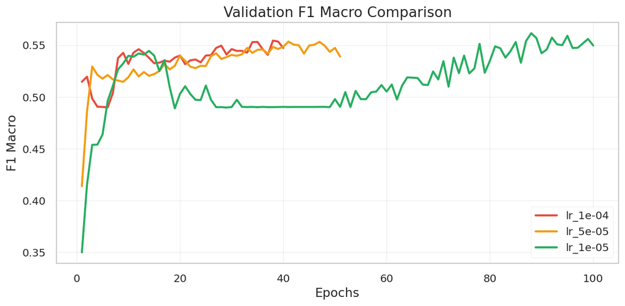

```python
# --- Plot metric curves for ALL learning rates (Sequential IDs) ---

print("\n" + "=" * 80)
print("Metric Curves for ALL FFNN (Sequential IDs) learning rates")
print("=" * 80)

plot_training_metrics(histories_seq, save_dir=save_dir, plot_name="ffnn_sequential_ids_f1_comparison")
```

```
================================================================================
Confusion matrices for ALL FFNN (Sequential IDs) learning rates - VALIDATION
================================================================================

Generating confusion matrix for FFNN (Sequential IDs) with lr=1e-04...
Saved plot: /content/drive/MyDrive/Projects/AImSecure/Laboratory2/results/images/task2_plots/cm_ffnn_sequential_ids_(lr=1e_04).png
```

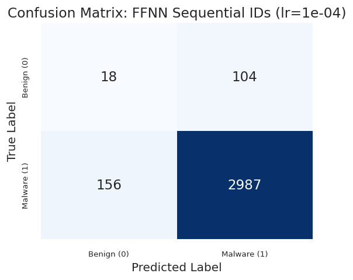

```
Generating confusion matrix for FFNN (Sequential IDs) with lr=5e-05...
Saved plot: /content/drive/MyDrive/Projects/AImSecure/Laboratory2/results/images/task2_plots/cm_ffnn_sequential_ids_(lr=5e_05).png
```

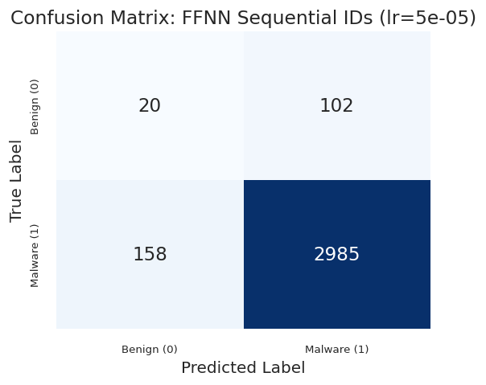

```
Generating confusion matrix for FFNN (Sequential IDs) with lr=1e-05...
Saved plot: /content/drive/MyDrive/Projects/AImSecure/Laboratory2/results/images/task2_plots/cm_ffnn_sequential_ids_(lr=1e_05).png
```

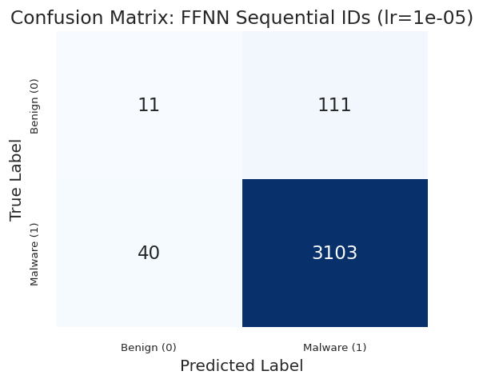

```python
# --- Plot confusion matrices for ALL learning rates (Sequential IDs) - VALIDATION ---

print("\n" + "=" * 80)
print("Confusion matrices for ALL FFNN (Sequential IDs) learning rates - VALIDATION")
print("=" * 80)

for lr in learning_rates_seq:
    model = models_seq[lr]
    print(f"\nGenerating confusion matrix for FFNN (Sequential IDs) with lr={lr:.0e}...")

    plot_cm_task2(model=model, X_tensor=X_val_tensor, y_tensor=y_val_tensor, model_name=f"FFNN Sequential IDs (lr={lr:.0e})", save_dir=save_dir)
```

```
================================================================================
Confusion matrices for ALL FFNN (Sequential IDs) learning rates - TEST
================================================================================

Generating confusion matrix for FFNN (Sequential IDs) with lr=1e-04...
Saved plot: /content/drive/MyDrive/Projects/AImSecure/Laboratory2/results/images/task2_plots/cm_ffnn_sequential_ids_(lr=1e_04).png
```

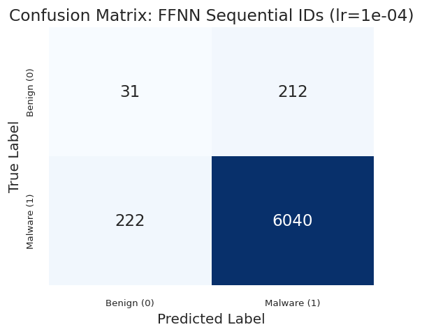

```
Generating confusion matrix for FFNN (Sequential IDs) with lr=5e-05...
Saved plot: /content/drive/MyDrive/Projects/AImSecure/Laboratory2/results/images/task2_plots/cm_ffnn_sequential_ids_(lr=5e_05).png
```

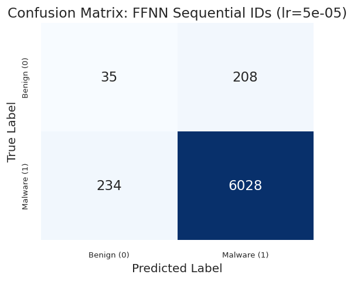

```
Generating confusion matrix for FFNN (Sequential IDs) with lr=1e-05...
Saved plot: /content/drive/MyDrive/Projects/AImSecure/Laboratory2/results/images/task2_plots/cm_ffnn_sequential_ids_(lr=1e_05).png
```

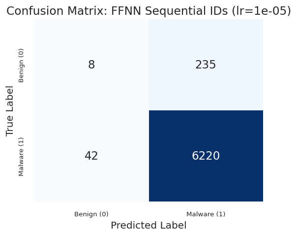

```python
# --- Plot confusion matrices for ALL learning rates (Sequential IDs) - TEST ---

print("\n" + "=" * 80)
print("Confusion matrices for ALL FFNN (Sequential IDs) learning rates - TEST")
print("=" * 80)

for lr in learning_rates_seq:
    model = models_seq[lr]
    print(f"\nGenerating confusion matrix for FFNN (Sequential IDs) with lr={lr:.0e}...")

    plot_cm_task2(model=model, X_tensor=X_test_tensor, y_tensor=y_test_tensor, model_name=f"FFNN Sequential IDs (lr={lr:.0e})", save_dir=save_dir)
```

#### Training with Learnable Embeddings Approach

```python
# --- Configuration Constants ---
seq_len = X_train.shape[1]
hidden_dims = [128, 64, 32]
dropout_rates = [0.4, 0.4, 0.4]
batchnorm_flags = [True, True, True]
min_delta = 0.00001
patience_early_stop = 15
epochs = 100

vocab_size = len(api_to_id)
embedding_dim = 128

# --- Device Setup (reuse from previous section if available) ---
device = torch.device('cuda' if torch.cuda.is_available() else 'cpu')
print(f"Using device: {device}")

# Compute weights and move to device
pos_weight = compute_pos_weight(y_train_split).to(device)

# --- Define LR Candidates ---
learning_rates_emb = [0.00005, 0.00001, 0.000005]
histories_emb = {}     # Store results here
models_emb = {}        # Store models here
elapsed_emb_times = {} # Store elapsed times here

print(f"\n{'='*80}")
print("Training FFNN (Learnable Embeddings) with different learning rates")
print(f"{'='*80}")

for lr in learning_rates_emb:
    print(f"\n--- Training FFNN (Learnable Embeddings) with lr={lr:.0e} ---")

    # Initialize model with embedding layer and move to device
    model_emb = MalwareFFNN(
        seq_len,
        hidden_dims,
        dropout_rates,
        batchnorm_flags,
        use_embedding=True,
        vocab_size=vocab_size,
        embedding_dim=embedding_dim,
    ).to(device)

    # Criterion (pos_weight already on device)
    criterion = nn.BCEWithLogitsLoss(pos_weight=pos_weight)

    # Initialize Optimizer
    optimizer = optim.AdamW(model_emb.parameters(), lr=lr, weight_decay=1e-4)

    # Setup Scheduler
    scheduler = torch.optim.lr_scheduler.ReduceLROnPlateau(
        optimizer,
        mode='min',
        factor=0.5,
        patience=5,
        min_lr=1e-6
    )

    # Train the model
    model_emb, history, elapsed_emb = train_model(
        model_emb,
        train_loader,
        val_loader,
        epochs,
        optimizer,
        criterion,
        min_delta,
        patience_early_stop,
        scheduler=None
    )

    # Store model and history with numeric LR key
    models_emb[lr] = model_emb
    histories_emb[lr] = history
    elapsed_emb_times[lr] = elapsed_emb

    elapsed_str = time.strftime('%H:%M:%S', time.gmtime(elapsed_emb))
    print(f"Completed. Training time: {elapsed_str} ({elapsed_emb:.2f}s) - Final val loss: {history['val_loss'][-1]:.4f}")
```

```
Using device: cuda
Negatives: 489, Positives: 12571
pos_weight (applied to y=1 samples): 0.2000

================================================================================
Training FFNN (Learnable Embeddings) with different learning rates
================================================================================

--- Training FFNN (Learnable Embeddings) with lr=5e-05 ---
Early stopping at epoch 36 (best val loss: 0.071219)

Training completed in 00:00:33 (hh:mm:ss) — 33.17 seconds
Completed. Training time: 00:00:33 (33.17s) - Final val loss: 0.0819

--- Training FFNN (Learnable Embeddings) with lr=1e-05 ---

Training completed in 00:01:32 (hh:mm:ss) — 92.36 seconds
Completed. Training time: 00:01:32 (92.36s) - Final val loss: 0.0714

--- Training FFNN (Learnable Embeddings) with lr=5e-06 ---

Training completed in 00:01:33 (hh:mm:ss) — 93.15 seconds
Completed. Training time: 00:01:33 (93.15s) - Final val loss: 0.1002
```

```
Saved plot: /content/drive/MyDrive/Projects/AImSecure/Laboratory2/results/images/task2_plots/ffnn_learnable_embeddings_lr_comparison.png
```

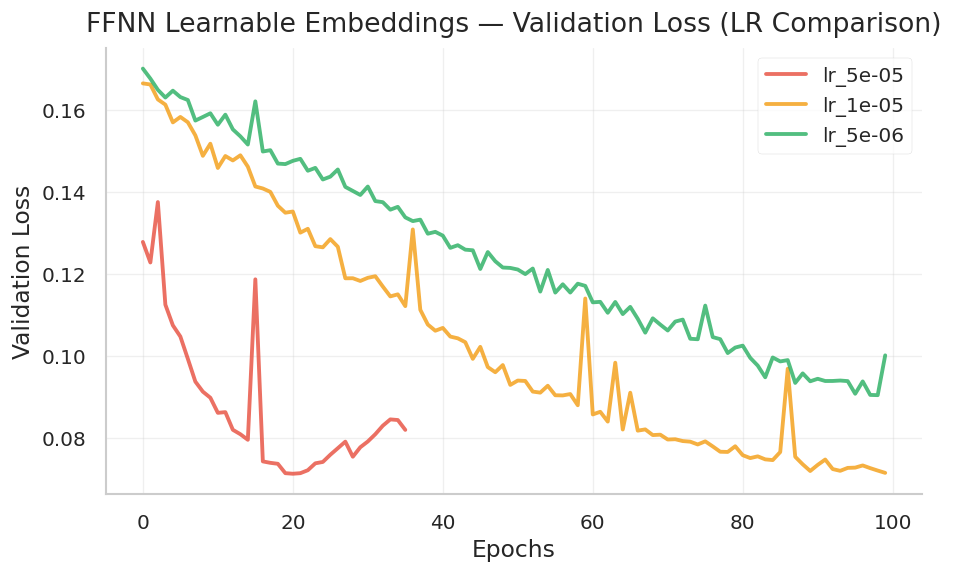

```
Saved plot: /content/drive/MyDrive/Projects/AImSecure/Laboratory2/results/images/task2_plots/ffnn_learnable_embeddings_diagnosis.png
```

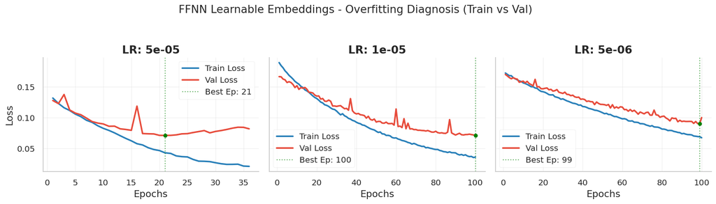

```python
# --- Plot loss curves ---

# Plot comparison
plot_lr_comparison(histories_emb, "FFNN Learnable Embeddings", save_dir)

# Plot Train vs Validation
plot_train_val_grid(histories_emb, "FFNN Learnable Embeddings", save_dir)
```

```python
# --- Evaluate validation and test sets for ALL learning rates ---

print("\n" + "=" * 80)
print("Evaluation for ALL FFNN (Learnable Embeddings) learning rates")
print("=" * 80)

for lr in learning_rates_emb:
    model = models_emb[lr]

    print(f"\n{'='*60}")
    print(f"FFNN (Learnable Embeddings) with lr={lr:.0e}")
    print(f"{'='*60}")

    # Validation evaluation
    print(f'\nValidation report (FFNN Learnable Embeddings - lr={lr:.0e}):')
    report = evaluate_model(model, X_val_tensor.to(device), y_val) # Moved X_val_tensor to device
    print(report)

    # Test evaluation
    print(f'Test report (FFNN Learnable Embeddings - lr={lr:.0e}):')
    report_test = evaluate_model(model, X_test_tensor.to(device), y_test) # Moved X_test_tensor to device
    print(report_test)

# Find and highlight best model
best_lr_emb = min(histories_emb.items(), key=lambda x: min(x[1]['val_loss']))
print(f"\n{'='*60}")
print(f"✓ Best FFNN (Learnable Embeddings) - LR: {best_lr_emb[0]:.0e} (Min Val Loss: {min(best_lr_emb[1]['val_loss']):.4f})")
print(f"{'='*60}")
```

```
================================================================================
Evaluation for ALL FFNN (Learnable Embeddings) learning rates
================================================================================

============================================================
FFNN (Learnable Embeddings) with lr=5e-05
============================================================

Validation report (FFNN Learnable Embeddings - lr=5e-05):
              precision    recall  f1-score   support

           0     0.3312    0.4180    0.3696       122
           1     0.9772    0.9672    0.9722      3143

    accuracy                         0.9467      3265
   macro avg     0.6542    0.6926    0.6709      3265
weighted avg     0.9530    0.9467    0.9497      3265

Test report (FFNN Learnable Embeddings - lr=5e-05):
              precision    recall  f1-score   support

           0     0.1676    0.2346    0.1955       243
           1     0.9698    0.9548    0.9623      6262

    accuracy                         0.9279      6505
   macro avg     0.5687    0.5947    0.5789      6505
weighted avg     0.9399    0.9279    0.9336      6505


============================================================
FFNN (Learnable Embeddings) with lr=1e-05
============================================================

Validation report (FFNN Learnable Embeddings - lr=1e-05):
              precision    recall  f1-score   support

           0     0.3355    0.4262    0.3755       122
           1     0.9775    0.9672    0.9723      3143

    accuracy                         0.9470      3265
```

[output cut: 27 more lines]

```

Test report (FFNN Learnable Embeddings - lr=5e-06):
              precision    recall  f1-score   support

           0     0.1388    0.3786    0.2031       243
           1     0.9742    0.9088    0.9404      6262

    accuracy                         0.8890      6505
   macro avg     0.5565    0.6437    0.5717      6505
weighted avg     0.9429    0.8890    0.9128      6505


============================================================
✓ Best FFNN (Learnable Embeddings) - LR: 5e-05 (Min Val Loss: 0.0712)
============================================================
```

```
================================================================================
Metric Curves for ALL FFNN (Learnable Embeddings) learning rates
================================================================================
Saved plot: /content/drive/MyDrive/Projects/AImSecure/Laboratory2/results/images/task2_plots/ffnn_learnable_embeddings_f1_comparison.png
```

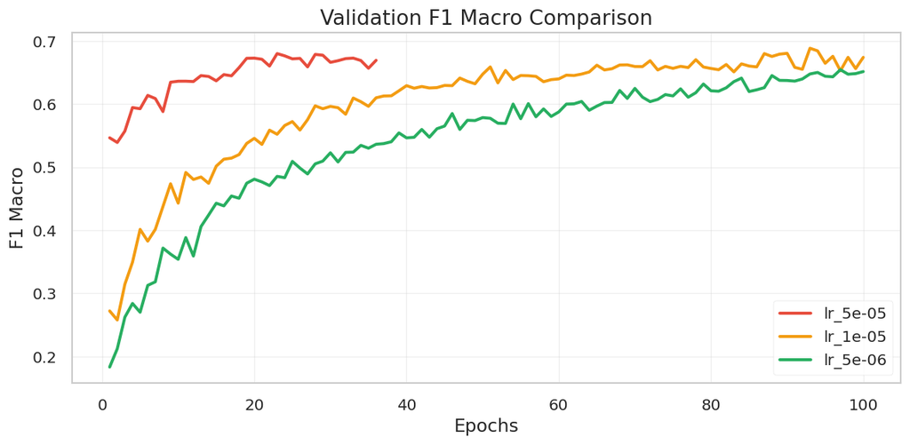

```python
# --- Plot metric curves for ALL learning rates (Learnable Embeddings) ---

print("\n" + "=" * 80)
print("Metric Curves for ALL FFNN (Learnable Embeddings) learning rates")
print("=" * 80)

# The plot_training_metrics function is designed to compare multiple histories.
plot_training_metrics(histories_emb, save_dir=save_dir, plot_name="ffnn_learnable_embeddings_f1_comparison")
```

```
================================================================================
Confusion matrices for ALL FFNN (Learnable Embeddings) learning rates - VALIDATION
================================================================================

Generating confusion matrix for FFNN (Learnable Embeddings) with lr=5e-05...
Saved plot: /content/drive/MyDrive/Projects/AImSecure/Laboratory2/results/images/task2_plots/cm_ffnn_learnable_embeddings_(lr=5e_05).png
```

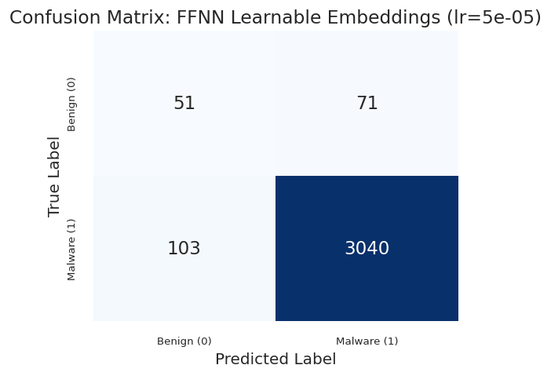

```
Generating confusion matrix for FFNN (Learnable Embeddings) with lr=1e-05...
Saved plot: /content/drive/MyDrive/Projects/AImSecure/Laboratory2/results/images/task2_plots/cm_ffnn_learnable_embeddings_(lr=1e_05).png
```

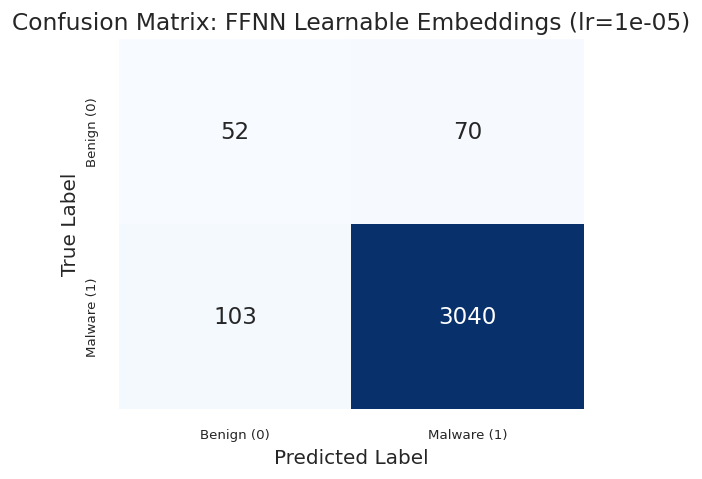

```
Generating confusion matrix for FFNN (Learnable Embeddings) with lr=5e-06...
Saved plot: /content/drive/MyDrive/Projects/AImSecure/Laboratory2/results/images/task2_plots/cm_ffnn_learnable_embeddings_(lr=5e_06).png
```

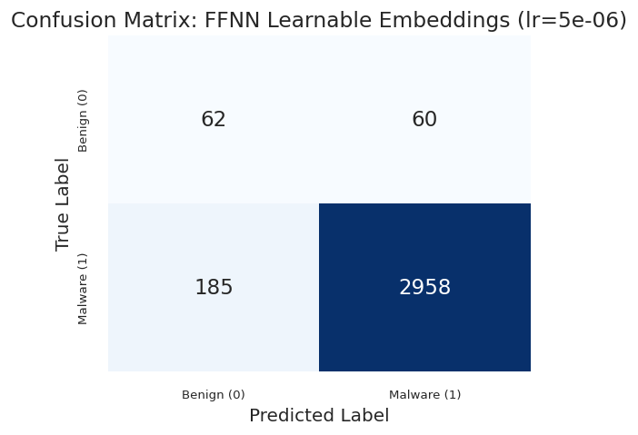

```python
# --- Plot confusion matrices for ALL learning rates (Learnable Embeddings) - VALIDATION ---

print("\n" + "=" * 80)
print("Confusion matrices for ALL FFNN (Learnable Embeddings) learning rates - VALIDATION")
print("=" * 80)

for lr in learning_rates_emb:
    model = models_emb[lr]
    print(f"\nGenerating confusion matrix for FFNN (Learnable Embeddings) with lr={lr:.0e}...")

    plot_cm_task2(model=model, X_tensor=X_val_tensor, y_tensor=y_val_tensor, model_name=f"FFNN Learnable Embeddings (lr={lr:.0e})", save_dir=save_dir)
```

```
================================================================================
Confusion matrices for ALL FFNN (Learnable Embeddings) learning rates - TEST
================================================================================

Generating confusion matrix for FFNN (Learnable Embeddings) with lr=5e-05...
Saved plot: /content/drive/MyDrive/Projects/AImSecure/Laboratory2/results/images/task2_plots/cm_ffnn_learnable_embeddings_(lr=5e_05).png
```

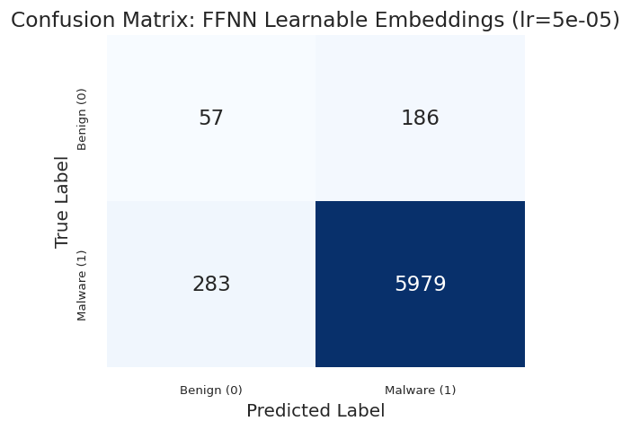

```
Generating confusion matrix for FFNN (Learnable Embeddings) with lr=1e-05...
Saved plot: /content/drive/MyDrive/Projects/AImSecure/Laboratory2/results/images/task2_plots/cm_ffnn_learnable_embeddings_(lr=1e_05).png
```

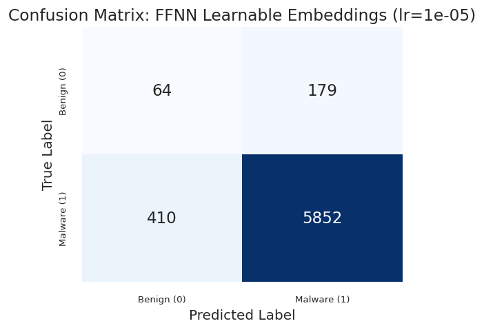

```
Generating confusion matrix for FFNN (Learnable Embeddings) with lr=5e-06...
Saved plot: /content/drive/MyDrive/Projects/AImSecure/Laboratory2/results/images/task2_plots/cm_ffnn_learnable_embeddings_(lr=5e_06).png
```

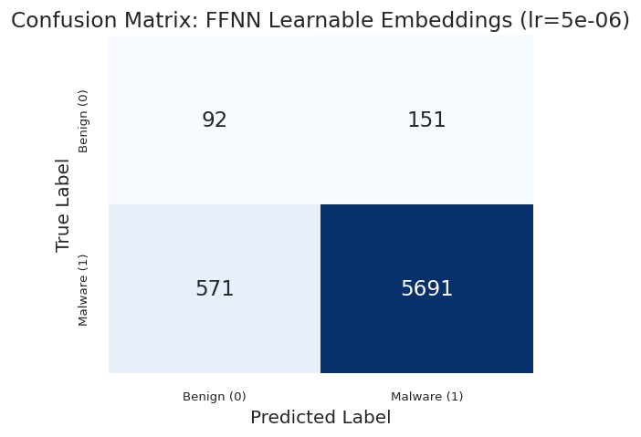

```python
# --- Plot confusion matrices for ALL learning rates (Learnable Embeddings) - TEST ---

print("\n" + "=" * 80)
print("Confusion matrices for ALL FFNN (Learnable Embeddings) learning rates - TEST")
print("=" * 80)

for lr in learning_rates_emb:
    model = models_emb[lr]
    print(f"\nGenerating confusion matrix for FFNN (Learnable Embeddings) with lr={lr:.0e}...")

    plot_cm_task2(model=model, X_tensor=X_test_tensor, y_tensor=y_test_tensor, model_name=f"FFNN Learnable Embeddings (lr={lr:.0e})", save_dir=save_dir)
```

#### Embedding size sensitivity analysis

To complete the learnable-embedding experiment, we keep the selected FFNN architecture and learning rate fixed, and vary only the embedding dimensionality. This isolates the effect of representation capacity from the effect of the optimizer or hidden-layer design.

```python
# --- Embedding size sensitivity analysis ---

# The LR grid above selects the best learning rate for the learnable-embedding FFNN.
# Here we keep that LR and the rest of the architecture fixed, changing only embedding_dim.
embedding_sizes = [8, 16, 32, 64, 128]
if 'best_lr_emb' not in globals():
    raise RuntimeError('Run the learnable-embedding LR selection cell before the embedding-size sweep.')
selected_embedding_lr = best_lr_emb[0]

histories_emb_size = {}
models_emb_size = {}
elapsed_emb_size_times = {}
embedding_size_rows = []

def predict_ffnn(model, X_tensor):
    """Return binary predictions for an FFNN model."""
    model.eval()
    model_device = next(model.parameters()).device
    with torch.no_grad():
        logits = model(X_tensor.to(model_device))
        probs = torch.sigmoid(logits)
        preds = (probs > 0.5).long().cpu().numpy().flatten()
    return preds

print(f"\n{'='*80}")
print("Embedding size sensitivity analysis for FFNN Learnable Embeddings")
print(f"Fixed learning rate: {selected_embedding_lr:.0e}")
print(f"Embedding sizes: {embedding_sizes}")
print(f"{'='*80}")

for emb_dim in embedding_sizes:
    print(f"\n--- Training FFNN Learnable Embeddings with embedding_dim={emb_dim} ---")

    model_emb_size = MalwareFFNN(
        seq_len,
        hidden_dims,
        dropout_rates,
        batchnorm_flags,
        use_embedding=True,
        vocab_size=vocab_size,
        embedding_dim=emb_dim,
    ).to(device)

    criterion = nn.BCEWithLogitsLoss(pos_weight=pos_weight)
    optimizer = optim.AdamW(model_emb_size.parameters(), lr=selected_embedding_lr, weight_decay=1e-4)

    model_emb_size, history, elapsed_emb_size = train_model(
        model_emb_size,
        train_loader,
        val_loader,
        epochs,
        optimizer,
        criterion,
        min_delta,
        patience=patience_early_stop,
        scheduler=None,
    )

    histories_emb_size[emb_dim] = history
    models_emb_size[emb_dim] = model_emb_size
    elapsed_emb_size_times[emb_dim] = elapsed_emb_size

    val_pred = predict_ffnn(model_emb_size, X_val_tensor)
    test_pred = predict_ffnn(model_emb_size, X_test_tensor)

    val_report = classification_report(y_val, val_pred, output_dict=True, zero_division=0)
    test_report = classification_report(y_test, test_pred, output_dict=True, zero_division=0)

    embedding_size_rows.append({
        'embedding_dim': emb_dim,
        'min_val_loss': min(history['val_loss']),
        'best_val_macro_f1_curve': max(history['val_f1_macro']),
        'val_macro_f1': val_report['macro avg']['f1-score'],
        'val_benign_recall': val_report['0']['recall'],
        'test_macro_f1': test_report['macro avg']['f1-score'],
        'test_benign_recall': test_report['0']['recall'],
        'training_time_s': elapsed_emb_size,
    })

embedding_size_results = pd.DataFrame(embedding_size_rows)
embedding_size_results = embedding_size_results.sort_values('embedding_dim').reset_index(drop=True)

print("\nEmbedding size comparison:")
display(embedding_size_results)

best_embedding_dim_row = embedding_size_results.loc[embedding_size_results['min_val_loss'].idxmin()]
best_embedding_dim = int(best_embedding_dim_row['embedding_dim'])
print(
    f"\nBest embedding size by minimum validation loss: {best_embedding_dim} "
    f"(min val loss = {best_embedding_dim_row['min_val_loss']:.4f}, "
    f"test macro F1 = {best_embedding_dim_row['test_macro_f1']:.4f})"
)
```

```
================================================================================
Embedding size sensitivity analysis for FFNN Learnable Embeddings
Fixed learning rate: 5e-05
Embedding sizes: [8, 16, 32, 64, 128]
================================================================================

--- Training FFNN Learnable Embeddings with embedding_dim=8 ---
Early stopping at epoch 58 (best val loss: 0.088485)

Training completed in 00:00:51 (hh:mm:ss) — 51.09 seconds

--- Training FFNN Learnable Embeddings with embedding_dim=16 ---
Early stopping at epoch 45 (best val loss: 0.082346)

Training completed in 00:00:39 (hh:mm:ss) — 39.54 seconds

--- Training FFNN Learnable Embeddings with embedding_dim=32 ---
Early stopping at epoch 50 (best val loss: 0.078678)

Training completed in 00:00:43 (hh:mm:ss) — 43.88 seconds

--- Training FFNN Learnable Embeddings with embedding_dim=64 ---
Early stopping at epoch 45 (best val loss: 0.074088)

Training completed in 00:00:39 (hh:mm:ss) — 39.59 seconds

--- Training FFNN Learnable Embeddings with embedding_dim=128 ---
Early stopping at epoch 39 (best val loss: 0.073032)

Training completed in 00:00:35 (hh:mm:ss) — 35.30 seconds

Embedding size comparison:
```

|  | embedding_dim | min_val_loss | best_val_macro_f1_curve | val_macro_f1 | val_benign_recall | test_macro_f1 | test_benign_recall | training_time_s |
| --- | --- | --- | --- | --- | --- | --- | --- | --- |
| 0 | 8 | 0.088485 | 0.607215 | 0.584713 | 0.319672 | 0.538210 | 0.218107 | 51.091888 |
| 1 | 16 | 0.082346 | 0.628196 | 0.603783 | 0.336066 | 0.556788 | 0.251029 | 39.538133 |
| 2 | 32 | 0.078678 | 0.663323 | 0.636757 | 0.360656 | 0.570540 | 0.259259 | 43.876767 |
| 3 | 64 | 0.074088 | 0.682119 | 0.675566 | 0.393443 | 0.590166 | 0.251029 | 39.585512 |
| 4 | 128 | 0.073032 | 0.675566 | 0.644022 | 0.377049 | 0.573982 | 0.288066 | 35.296682 |

```
Best embedding size by minimum validation loss: 128 (min val loss = 0.0730, test macro F1 = 0.5740)
```

```
Saved plot: /content/drive/MyDrive/Projects/AImSecure/Laboratory2/results/images/task2_plots/ffnn_embedding_size_comparison.png
```

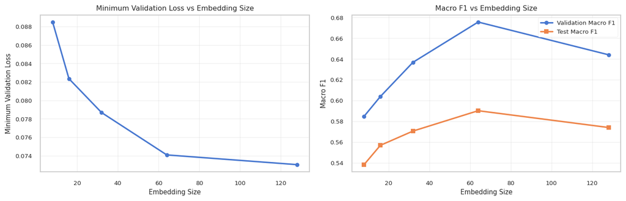

```
Saved plot: /content/drive/MyDrive/Projects/AImSecure/Laboratory2/results/images/task2_plots/ffnn_embedding_size_f1_comparison.png
```

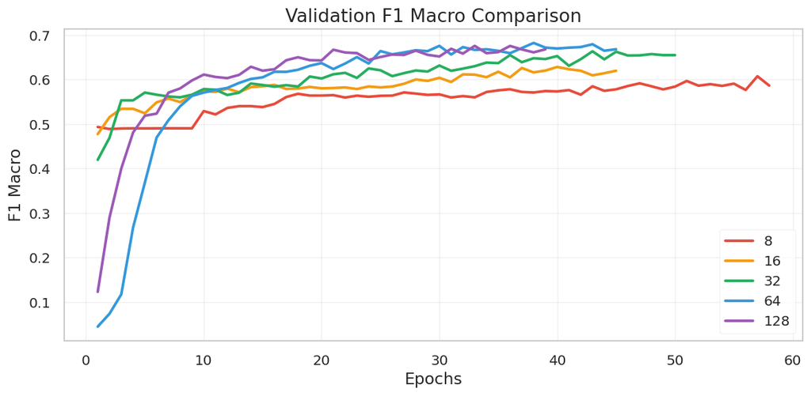

```python
# --- Plot embedding size comparison ---

fig, axes = plt.subplots(1, 2, figsize=(12, 4))

axes[0].plot(
    embedding_size_results['embedding_dim'],
    embedding_size_results['min_val_loss'],
    marker='o',
    linewidth=2,
)
axes[0].set_title('Minimum Validation Loss vs Embedding Size')
axes[0].set_xlabel('Embedding Size')
axes[0].set_ylabel('Minimum Validation Loss')
axes[0].grid(True, alpha=0.3)

axes[1].plot(
    embedding_size_results['embedding_dim'],
    embedding_size_results['val_macro_f1'],
    marker='o',
    linewidth=2,
    label='Validation Macro F1',
)
axes[1].plot(
    embedding_size_results['embedding_dim'],
    embedding_size_results['test_macro_f1'],
    marker='s',
    linewidth=2,
    label='Test Macro F1',
)
axes[1].set_title('Macro F1 vs Embedding Size')
axes[1].set_xlabel('Embedding Size')
axes[1].set_ylabel('Macro F1')
axes[1].grid(True, alpha=0.3)
axes[1].legend()

plt.tight_layout()
if save_dir:
    save_plot(fig, 'ffnn_embedding_size_comparison', save_dir)
plt.show()

# Optional: compare the validation macro F1 curves across embedding sizes.
plot_training_metrics(
    histories_emb_size,
    save_dir=save_dir,
    plot_name='ffnn_embedding_size_f1_comparison'
)
```

#### Q: Use a FFNN in both cases. Report how you selected the hyperparameters of your final model, and justify your choices.

For Task 2, we implemented two FFNN configurations: one using raw sequential identifiers and one using learnable embeddings. In both cases, model selection used validation loss as the primary criterion, while validation macro F1 was monitored because the dataset is strongly imbalanced and accuracy alone would hide poor behavior on the benign class.

**Sequential identifiers.** The sequential-ID model receives a fixed-length vector of 90 API identifiers. We used a funnel-shaped architecture with hidden dimensions `[256, 128, 64]`, Batch Normalization, Dropout, AdamW, and `BCEWithLogitsLoss`. The tested learning rates were `1e-4`, `5e-5`, and `1e-5`. The selected configuration is `lr=1e-4`, which reaches the lowest validation loss (`0.0921`) and validation macro F1 `0.5400`. On the test set, it obtains accuracy `93.33%` and macro F1 `0.5452`.

**Learnable embeddings.** The embedding-based model first maps each API identifier into a continuous vector and then flattens the embedded sequence before the dense layers. We used hidden dimensions `[128, 64, 32]`, Batch Normalization, Dropout, AdamW, and the same early-stopping strategy. The tested learning rates were `5e-5`, `1e-5`, and `5e-6`; the selected learning rate is `5e-5`, with validation loss `0.0712` and validation macro F1 `0.6709`. On the test set, this selected model reaches accuracy `92.79%` and macro F1 `0.5789`.

To address the requirement of testing different embedding sizes, we then fixed the selected learning rate (`5e-5`) and repeated the experiment with embedding dimensions `[8, 16, 32, 64, 128]`. The validation macro F1 generally improves as the representation becomes richer: it goes from `0.5847` with dimension 8 to `0.6756` with dimension 64. The lowest validation loss is obtained with dimension 128 (`0.0730`), while the best validation macro F1 is obtained with dimension 64 (`0.6756`). On the test set, dimension 64 reaches macro F1 `0.5902`, slightly above the selected-loss dimension 128 (`0.5740`). This suggests that larger embeddings help, but the gain is modest and still limited by the FFNN fixed-length representation.

The loss uses `pos_weight=0.20` because label 1 corresponds to malware, which is the majority class. In `BCEWithLogitsLoss`, this down-weights malware errors and gives more relative influence to the minority benign samples during optimization.

#### Q: Can you obtain the same results for sequential identifiers and learnable embeddings? If not, why?

No. The learnable-embedding representation performs better than raw sequential identifiers, especially when looking at validation macro F1 and benign-class behavior. The sequential-ID model treats API identifiers as ordinary numerical values, implicitly suggesting that nearby IDs have a meaningful numerical relationship. This is not true: the assignment of IDs is arbitrary, so the network may exploit accidental magnitudes rather than semantic similarity between API calls.

Learnable embeddings reduce this limitation by mapping each API call into a continuous vector space. During training, the model can learn representations that make API calls with similar roles or similar discriminative behavior easier to use jointly. This is reflected in the selected validation results: the best sequential-ID model reaches validation macro F1 `0.5400`, while the embedding-based model reaches `0.6709` with the selected learning rate.

The embedding-size experiment also shows that the embedding mechanism is useful, but not unlimited. Very small embeddings, such as dimension 8, do not provide enough representation capacity and obtain lower macro F1. Larger embeddings improve validation performance, with dimension 64 giving the best validation macro F1 (`0.6756`) and dimension 128 giving the lowest validation loss (`0.0730`). On the test set, dimension 64 obtains macro F1 `0.5902`, while dimension 128 obtains `0.5740`, suggesting that extra capacity helps only up to a point and does not fully solve the FFNN limitations.

Overall, learnable embeddings are preferable to sequential identifiers, but the FFNN remains limited by the fixed-length representation. Since sequences longer than 90 calls must be truncated, and since the dense network cannot explicitly model temporal dependencies, both FFNN variants remain weaker than the later RNN and GNN models.

```python
# =============================================================================
# FINAL SUMMARY
# =============================================================================

# Helper function to extract macro avg from the best FFNN model
def get_macro_avg_stats_ffnn(model, X_tensor):
    """
    Predict and get macro average statistics for an FFNN model.
    """
    # Get the device from the model itself
    device = next(model.parameters()).device

    model.eval()
    with torch.no_grad():
        outputs = model(X_tensor.to(device)) # Move input tensor to device
        probs = torch.sigmoid(outputs)
        y_pred = (probs > 0.5).long().cpu().numpy().flatten()

    y_true = y_val  # Using validation set
    report_dict = classification_report(y_true, y_pred, output_dict=True, zero_division=0)
    return report_dict['macro avg']

# --- 1. Prepare Stats for FFNN Sequential IDs ---
best_model_seq_obj = models_seq[best_lr_seq[0]]
macro_seq = get_macro_avg_stats_ffnn(best_model_seq_obj, X_val_tensor)

# --- 2. Prepare Stats for FFNN Learnable Embeddings ---
best_model_emb_obj = models_emb[best_lr_emb[0]]
macro_emb = get_macro_avg_stats_ffnn(best_model_emb_obj, X_val_tensor)

# --- PRINTING THE REPORT ---

print("\n" + "=" * 100)
print("TASK 2 SUMMARY: Best Learning Rates & Macro Avg Performance")
print("=" * 100)
# Header for the manual table
print(f"{'Model':<30} | {'Best LR':<10} | {'Val Loss':<10} | {'Macro P':<8} {'Macro R':<8} {'Macro F1':<8} | {'Time':<10}")
print("-" * 100)

# 1. FFNN Sequential IDs
t_seq = time.strftime('%H:%M:%S', time.gmtime(elapsed_seq_times[best_lr_seq[0]]))
print(f"{'FFNN (Sequential IDs)':<30} | {best_lr_seq[0]:.0e}      | {min(best_lr_seq[1]['val_loss']):.4f}     | "
      f"{macro_seq['precision']:.4f}   {macro_seq['recall']:.4f}   {macro_seq['f1-score']:.4f}   | {t_seq}")

# 2. FFNN Learnable Embeddings
t_emb = time.strftime('%H:%M:%S', time.gmtime(elapsed_emb_times[best_lr_emb[0]]))
print(f"{'FFNN (Learnable Embeddings)':<30} | {best_lr_emb[0]:.0e}      | {min(best_lr_emb[1]['val_loss']):.4f}     | "
      f"{macro_emb['precision']:.4f}   {macro_emb['recall']:.4f}   {macro_emb['f1-score']:.4f}   | {t_emb}")

# --- 3. Optional Embedding Size Summary ---
if 'embedding_size_results' in globals():
    best_emb_loss_row = embedding_size_results.loc[embedding_size_results['min_val_loss'].idxmin()]
    best_emb_f1_row = embedding_size_results.loc[embedding_size_results['val_macro_f1'].idxmax()]

    print("\n" + "=" * 100)
    print("EMBEDDING SIZE SENSITIVITY SUMMARY")
    print("=" * 100)
    print(
        f"Best by min validation loss: dim={int(best_emb_loss_row['embedding_dim'])} | "
        f"val loss={best_emb_loss_row['min_val_loss']:.4f} | "
        f"val macro F1={best_emb_loss_row['val_macro_f1']:.4f} | "
        f"test macro F1={best_emb_loss_row['test_macro_f1']:.4f} | "
        f"time={best_emb_loss_row['training_time_s']:.2f}s"
    )
    print(
        f"Best by validation macro F1: dim={int(best_emb_f1_row['embedding_dim'])} | "
        f"val loss={best_emb_f1_row['min_val_loss']:.4f} | "
        f"val macro F1={best_emb_f1_row['val_macro_f1']:.4f} | "
        f"test macro F1={best_emb_f1_row['test_macro_f1']:.4f} | "
        f"time={best_emb_f1_row['training_time_s']:.2f}s"
    )
```

```
====================================================================================================
TASK 2 SUMMARY: Best Learning Rates & Macro Avg Performance
====================================================================================================
Model                          | Best LR    | Val Loss   | Macro P  Macro R  Macro F1 | Time
----------------------------------------------------------------------------------------------------
FFNN (Sequential IDs)          | 1e-04      | 0.0921     | 0.5349   0.5490   0.5400   | 00:00:32
FFNN (Learnable Embeddings)    | 5e-05      | 0.0712     | 0.6542   0.6926   0.6709   | 00:00:33

====================================================================================================
EMBEDDING SIZE SENSITIVITY SUMMARY
====================================================================================================
Best by min validation loss: dim=128 | val loss=0.0730 | val macro F1=0.6440 | test macro F1=0.5740 | time=35.30s
Best by validation macro F1: dim=64 | val loss=0.0741 | val macro F1=0.6756 | test macro F1=0.5902 | time=39.59s
```

## Task 3 - Recursive Neural Network (RNN)

```python
# Create directory for plots
save_dir = results_path + 'images/' + 'task3_plots/'
os.makedirs(save_dir, exist_ok=True)
```

```python
# --- Choose number of epochs depending on device (GPU vs CPU) ---

device = torch.device('cuda' if torch.cuda.is_available() else 'cpu')

# Use fewer epochs when running on CPU to avoid extremely long runs
if torch.cuda.is_available():
    num_epochs = 150
else:
    num_epochs = 15

print(f"Number of epochs: {num_epochs}")
```

```
Number of epochs: 150
```

### Sequence Modeling with RNNs

```python
# --- Build vocabulary and API-to-ID mappings from training data ---

def build_vocab_from_train(df_train, seq_col="api_call_sequence"):
    """
    Extract the set of unique API calls from the training set only.
    Returns a sorted list of API call names (vocab).
    """
    vocab = sorted({api for seq in df_train[seq_col] for api in seq})
    return vocab

def build_api_mappings(vocab):
    """
    Create dictionaries mapping API names to integer IDs and vice versa.
    Reserves indices 0 and 1 for <PAD> and <UNK> special tokens.
    """
    api_to_id = {"<PAD>": PAD_IDX, "<UNK>": UNK_IDX}
    for i, api in enumerate(vocab):
        api_to_id[api] = i + 2  # start after PAD/UNK
    id_to_api = {i: api for api, i in api_to_id.items()}
    return api_to_id, id_to_api

# Build vocabulary from training data only (no data leakage)
vocab_train = build_vocab_from_train(df_train)
api_to_id, id_to_api = build_api_mappings(vocab_train)
```

```python
# --- Encode API call sequences to integer IDs ---

def encode_sequences(df, api_to_id, seq_col="api_call_sequence", label_col="is_malware", max_len=None):
    """
    Convert API call sequences to lists of integer IDs using the mapping.
    Unknown API calls (not seen in training) are mapped to <UNK> (PAD_IDX).
    Optionally truncate sequences to max_len (but we preserve full length for RNNs).
    """
    seqs, labels = [], []
    for seq, y in zip(df[seq_col], df[label_col]):
        ids = [api_to_id.get(api, PAD_IDX) for api in seq]
        if max_len is not None:
            ids = ids[:max_len]  # only if you explicitly choose to truncate
        seqs.append(ids)
        labels.append(int(y))
    return seqs, labels

# Encode training and test sequences (no truncation - RNNs handle variable lengths)
train_seqs, train_labels = encode_sequences(df_train, api_to_id)
test_seqs, test_labels = encode_sequences(df_test, api_to_id)
```

```python
# --- Split training data into train/validation subsets ---

# Create indices for stratified train/val split (preserves class balance)
idx = list(range(len(train_seqs)))
train_idx, val_idx = train_test_split(
    idx, test_size=0.2, random_state=42, stratify=train_labels
)

def subset_by_idx(seqs, labels, indices):
    """Helper to extract sequences and labels at given indices."""
    return [seqs[i] for i in indices], [labels[i] for i in indices]

# Create training and validation subsets
train_seqs_sub, train_labels_sub = subset_by_idx(train_seqs, train_labels, train_idx)
val_seqs_sub, val_labels_sub = subset_by_idx(train_seqs, train_labels, val_idx)
```

```python
# --- Define PyTorch Dataset for variable-length sequences ---

class SeqDataset(torch.utils.data.Dataset):
    """
    A PyTorch Dataset that wraps sequences and their labels.
    Each item returns a tensor of API IDs and a scalar label.
    Note: Sequences have variable lengths at this stage.
    """
    def __init__(self, sequences, labels):
        self.sequences = sequences
        self.labels = labels

    def __len__(self):
        return len(self.sequences)

    def __getitem__(self, idx):
        x = torch.tensor(self.sequences[idx], dtype=torch.long)
        y = torch.tensor(self.labels[idx], dtype=torch.float32) # scalar
        return x, y
```

```python
# --- Custom collate function for padding and packing ---

def collate_fn(batch):
    """
    Custom collate function for DataLoader:
    1. Sorts sequences by length (descending) - required for pack_padded_sequence
    2. Pads all sequences to the max length in this batch
    3. Returns padded sequences, original lengths, and labels (CPU tensors)
    Note: Device transfer is handled by the training loop, not the collate function.
    """
    sequences, labels = zip(*batch)

    # Compute original lengths before padding
    lengths = torch.tensor([len(s) for s in sequences], dtype=torch.long)
    # Sort by length (descending) for pack_padded_sequence compatibility
    lengths_sorted, perm_idx = lengths.sort(descending=True)

    # Reorder sequences and labels according to sorted indices
    sequences = [sequences[i] for i in perm_idx]
    labels = torch.stack([labels[i] for i in perm_idx]).unsqueeze(1)  # (B,1)

    # Pad sequences to max length in batch (dynamic padding)
    padded = pad_sequence(sequences, batch_first=True, padding_value=PAD_IDX)

    # Return CPU tensors - training loop handles device transfer
    return padded, lengths_sorted, labels
```

```python
# --- Create DataLoaders with custom collate function ---

# Wrap sequences in Dataset objects
train_ds = SeqDataset(train_seqs_sub, train_labels_sub)
val_ds = SeqDataset(val_seqs_sub, val_labels_sub)
test_ds = SeqDataset(test_seqs, test_labels)

# Create DataLoaders with dynamic padding via collate_fn
# Note: collate_fn handles variable-length sequences by padding per batch
rnn_train_generator = torch.Generator()
rnn_train_generator.manual_seed(42)
train_loader = DataLoader(
    train_ds,
    batch_size=64,
    shuffle=True,
    collate_fn=collate_fn,
    generator=rnn_train_generator,
)
val_loader = DataLoader(val_ds, batch_size=64, shuffle=False, collate_fn=collate_fn)
test_loader = DataLoader(test_ds, batch_size=64, shuffle=False, collate_fn=collate_fn)
```

#### Q: With RNNs, do you still have to pad your data? If yes, how?

Yes. RNNs can process sequences of different lengths in principle, but mini-batch training still requires tensors with a consistent shape inside each batch. For this reason, we pad the sequences dynamically at batch level rather than padding every sequence to a global fixed length.

The custom `collate_fn` sorts the samples in each batch by decreasing sequence length, pads only up to the longest sequence in that batch, and returns both the padded tensor and the original lengths. The embedding layer uses `padding_idx=0`, so the padding token has a dedicated embedding. Then, before the recurrent layer, we use `torch.nn.utils.rnn.pack_padded_sequence`, which tells the RNN to ignore padded positions during the recurrent computation.

This approach keeps the batch representation compatible with PyTorch while avoiding hidden-state updates on dummy tokens.

#### Q: Do you have to truncate the testing sequences? Justify your answer with your understanding of why it is/it is not the case.

No. Unlike an FFNN, an RNN does not have a fixed input layer tied to a specific sequence length. The same recurrent weights are reused at every time step, so a longer test sequence simply produces more recurrent updates.

In our implementation, padding and `pack_padded_sequence` are used only to manage batches efficiently. They do not impose the fixed length of 90 used in the FFNN. Therefore, test sequences longer than the maximum training length do not need to be truncated for architectural reasons.

Avoiding truncation is important because API calls near the end of a trace may contain useful behavioral information. Truncating them would remove part of the execution context, while the recurrent model can process the full sequence within normal memory limits.

```python
# Reusable training loop for RNN-like modules
def train_rnn_common(model, train_loader, val_loader, optimizer, criterion, epochs, min_delta=None, patience=None, scheduler=None):
      """
      A generic training loop for RNN-based models that supports early stopping.
      Now also tracks validation F1 macro score.
      """
      device = next(model.parameters()).device

      best_val_f1 = float('-inf')
      best_val_loss = math.inf
      best_epoch = 0
      best_state = None
      trigger = 0
      history = {'train_loss': [], 'val_loss': [], 'val_f1_macro': []}
      start_time = time.time()

      for epoch in range(1, epochs+1):
          # --- Training Phase ---
          model.train()
          train_losses = []
          for X_batch, lengths, y_batch in train_loader:
              X_batch, y_batch = X_batch.to(device), y_batch.to(device)
              optimizer.zero_grad()
              outputs = model(X_batch, lengths)
              loss = criterion(outputs, y_batch)
              loss.backward()
              torch.nn.utils.clip_grad_norm_(model.parameters(), max_norm=1.0)
              optimizer.step()
              train_losses.append(loss.item())
          train_loss = float(np.mean(train_losses)) if train_losses else 0.0

          # --- Validation Phase ---
          model.eval()
          val_losses = []
          all_preds = []
          all_targets = []
          with torch.no_grad():
              for X_batch, lengths, y_batch in val_loader:
                  X_batch, y_batch = X_batch.to(device), y_batch.to(device)
                  outputs = model(X_batch, lengths)
                  loss = criterion(outputs, y_batch)
                  val_losses.append(loss.item())

                  # Collect predictions for F1 score
                  probs = torch.sigmoid(outputs).view(-1)
                  preds = (probs > 0.5).long()
                  all_preds.extend(preds.cpu().tolist())
                  all_targets.extend(y_batch.view(-1).cpu().tolist())

          val_loss = float(np.mean(val_losses)) if val_losses else 0.0
          val_f1_macro = f1_score(all_targets, all_preds, average='macro', zero_division=0)

          history['train_loss'].append(train_loss)
          history['val_loss'].append(val_loss)
          history['val_f1_macro'].append(val_f1_macro)

          # --- Scheduler Step ---
          if scheduler is not None:
              last_lr = optimizer.param_groups[0]['lr']
              if isinstance(scheduler, torch.optim.lr_scheduler.ReduceLROnPlateau):
                  scheduler.step(val_loss)
              else:
                  scheduler.step()
              curr_lr = optimizer.param_groups[0]['lr']
              if curr_lr != last_lr:
                  print(f"Epoch {epoch}: LR reduced from {last_lr:.6f} to {curr_lr:.6f}")

          if (epoch % 5 == 0) or (epoch == 1) or (epoch == epochs):
              print(f'Epoch {epoch}/{epochs} - Train Loss: {train_loss:.4f} - Val Loss: {val_loss:.4f} - Val F1: {val_f1_macro:.4f}')

          # --- Checkpointing and early stopping on validation macro F1 ---
          f1_delta = min_delta if min_delta is not None else 0
          f1_improved = val_f1_macro > best_val_f1 + f1_delta
          f1_tied = abs(val_f1_macro - best_val_f1) <= f1_delta
          loss_improved_on_tie = f1_tied and val_loss < best_val_loss

          if f1_improved or loss_improved_on_tie:
              best_val_f1 = val_f1_macro
              best_val_loss = val_loss
              best_epoch = epoch
              best_state = {k: v.cpu().clone() for k, v in model.state_dict().items()}
              trigger = 0
          else:
              trigger += 1
              if trigger >= patience:
                  print(
                      f'Early stopping at epoch {epoch} '
                      f'(best val macro F1 {best_val_f1:.4f} at epoch {best_epoch}, '
                      f'val loss {best_val_loss:.6f})'
                  )
                  break

      elapsed = time.time() - start_time

      if best_state is not None:
          model.load_state_dict(best_state)
          model.to(device)

      history['best_epoch'] = best_epoch
      history['best_val_f1_macro'] = best_val_f1
      history['best_val_loss_at_checkpoint'] = best_val_loss

      return model, history, elapsed
```

```python
# Prediction helper (binary classification threshold)
def predict_loader(model, loader):
    """
    Run the model on a DataLoader and return integer arrays for
    ground-truth labels and predicted labels (0/1).
    """
    # Set model to evaluation mode (e.g., disables dropout)
    model.eval()

    # Detect device from model parameters
    device = next(model.parameters()).device

    ys_true = [] # To store all true labels
    ys_pred = [] # To store all predicted labels

    # Disable gradient calculations to save memory and computation
    with torch.no_grad():
        # Iterate over all batches in the data loader
        for X_batch, lengths, y_batch in loader:
            # Move batch to device
            X_batch = X_batch.to(device)

            # Get model outputs (logits)
            out = model(X_batch, lengths)

            # Convert logits to probabilities using sigmoid
            probs = torch.sigmoid(out).cpu().numpy().ravel()

            # Apply threshold for binary classification
            preds = (probs >= 0.5).astype(int)

            # Store the ground-truth and predicted labels from this batch
            ys_true.extend(y_batch.cpu().numpy().ravel().astype(int).tolist())
            ys_pred.extend(preds.tolist())

    # Convert the lists of all labels/preds into final numpy arrays
    return np.array(ys_true, dtype=int), np.array(ys_pred, dtype=int)
```

```python
def plot_cm_task3(model, loader, model_name, save_dir=None):
    """
    Specific for RNNs. Uses your existing 'predict_loader' logic.
    """
    # Use the helper function you already defined in the notebook
    y_true, y_pred = predict_loader(model, loader)

    # Plot
    _internal_plot_cm(y_true, y_pred, model_name, save_dir)
```

```python
# Function to train a model with a specific learning rate
def set_rnn_seed(seed=42):
    """Reset random state before every RNN experiment."""
    random.seed(seed)
    np.random.seed(seed)
    torch.manual_seed(seed)
    if torch.cuda.is_available():
        torch.cuda.manual_seed_all(seed)


def train_with_lr(
    model_class, model_params, initial_lr, train_loader, val_loader,
    criterion, num_epochs, min_delta, patience, scheduler_params, device,
    weight_decay=1e-4, seed=42,
):
    """
    Train a model with a specific initial learning rate and return the history.
    """
    set_rnn_seed(seed)
    if getattr(train_loader, 'generator', None) is not None:
        train_loader.generator.manual_seed(seed)

    # Create a fresh instance of the model
    model = model_class(**model_params).to(device)

    # Create optimizer with the specified learning rate
    optimizer = optim.AdamW(model.parameters(), lr=initial_lr, weight_decay=weight_decay)

    # Create scheduler
    scheduler = torch.optim.lr_scheduler.ReduceLROnPlateau(
        optimizer,
        **scheduler_params
    )

    # Train the model
    model, history, elapsed = train_rnn_common(
        model,
        train_loader,
        val_loader,
        optimizer,
        criterion,
        epochs=num_epochs,
        min_delta=min_delta,
        patience=patience,
        scheduler=scheduler
    )

    return model, history, elapsed


def select_best_rnn_model(architecture_name, models, histories, val_loader):
    """Select a restored RNN model using validation metrics only."""
    rows = []

    for lr, model in models.items():
        y_val_true, y_val_pred = predict_loader(model, val_loader)
        report = classification_report(
            y_val_true, y_val_pred, output_dict=True, zero_division=0
        )
        rows.append({
            'learning_rate': lr,
            'val_macro_f1': report['macro avg']['f1-score'],
            'val_accuracy': report['accuracy'],
            'checkpoint_val_loss': histories[lr]['best_val_loss_at_checkpoint'],
            'checkpoint_epoch': histories[lr]['best_epoch'],
        })

    selection_table = pd.DataFrame(rows).sort_values(
        by=['val_macro_f1', 'val_accuracy', 'checkpoint_val_loss'],
        ascending=[False, False, True],
    ).reset_index(drop=True)

    best_lr = float(selection_table.loc[0, 'learning_rate'])
    print(f"\nAutomatic selection for {architecture_name}")
    print("Ranking criterion: validation macro F1, then validation accuracy, then checkpoint validation loss")
    print(selection_table.to_string(index=False))
    print(
        f"Selected {architecture_name}: lr={best_lr:.0e}, "
        f"validation macro F1={selection_table.loc[0, 'val_macro_f1']:.4f}, "
        f"checkpoint epoch={int(selection_table.loc[0, 'checkpoint_epoch'])}"
    )

    return best_lr, selection_table
```

#### Q: Is the RNN padding more memory efficient compared to the FFNN's one? Why?

Yes, the RNN padding strategy is more efficient than the FFNN fixed-length strategy. In Task 2, every sequence must be converted into the same global length of 90 before entering the FFNN. This means that shorter sequences still occupy the full fixed-size input vector, and longer test sequences must be truncated.

In Task 3, padding is performed only inside each mini-batch, up to the longest sequence in that batch. Moreover, `pack_padded_sequence` prevents the recurrent layer from computing hidden-state transitions on padding tokens. The padded tensor still exists for batching, but the expensive recurrent computation is focused on real API calls.

This makes the RNN approach more flexible and usually more memory/computation efficient for variable-length sequences, especially when sequence lengths differ substantially across samples.

```python
# --- Variation 1: Simple one-directional RNN (nn.RNN) ---

class SimpleRNNClassifier(nn.Module):
    def __init__(self, vocab_size, embed_dim=32, hidden_size=128, num_layers=2, num_classes=1, bidirectional=False, dropout=0.25, padding=0):
        super(SimpleRNNClassifier, self).__init__()

        # Embedding layer: Maps vocabulary indices (integers) to dense vectors (embeddings).
        # padding_idx=0 ensures the padding token doesn't contribute to gradients.
        self.embedding = nn.Embedding(vocab_size, embedding_dim=embed_dim, padding_idx=padding)

        # Simple RNN layer: Processes the embedded sequences.
        self.rnn = nn.RNN(
            input_size=embed_dim,
            hidden_size=hidden_size,
            num_layers=num_layers,
            batch_first=True,
            nonlinearity='tanh',
            bidirectional=bidirectional,
            dropout=dropout if num_layers > 1 else 0.0,
        )

        self.bidirectional = bidirectional
        fc_in = hidden_size * (2 if bidirectional else 1)

        # Final fully connected layer for classification.
        self.fc = nn.Linear(fc_in, num_classes)
        self.dropout = nn.Dropout(dropout)

    def forward(self, x, lengths):
        # Embed the input indices
        emb = self.embedding(x) # Shape: (batch_size, max_seq_len, embed_dim)
        emb = self.dropout(emb)

        # Pack the sequence to let the RNN ignore padding
        packed = pack_padded_sequence(emb, lengths.cpu(), batch_first=True, enforce_sorted=True)

        # Process the packed sequence through the RNN
        packed_out, hn = self.rnn(packed) # hn is the final hidden state(s)

        # hn shape: (num_layers * num_directions, batch_size, hidden_size)

        # Get the final hidden state to represent the whole sequence.
        if self.bidirectional:
            # Concatenate the final forward (hn[-2]) and backward (hn[-1]) states
            h_last = torch.cat([hn[-2], hn[-1]], dim=1)
        else:
            # Use the final hidden state from the last layer (hn[-1])
            h_last = hn[-1]

        # Pass the final hidden state through the classifier
        out = self.fc(h_last)
        return out
```

```python
# --- Variation 1: Simple Unidirectional RNN ---

print("\n" + "=" * 80)
print("Training Simple RNN with different learning rates")
print("=" * 80)

# Define learning rates to test
learning_rates = [2e-04, 1e-04, 8e-05, 5e-05]

# Model parameters
vocab_size_rnn = len(api_to_id)
simple_rnn_params = {
    'vocab_size': vocab_size_rnn,
    'embed_dim': 32,
    'hidden_size': 128,
    'num_layers': 2,
    'num_classes': 1,
    'bidirectional': False,
    'dropout': 0.3
}

# Initialize early stopping parameters
min_delta = 0.00001
patience = 20

# Compute class balance from training subset and set pos_weight for BCEWithLogitsLoss
pos = sum(train_labels_sub) # number of positive (1) samples
neg = len(train_labels_sub) - pos

# Compute weights
pos_weight = compute_pos_weight(train_labels_sub).to(device)

criterion = nn.BCEWithLogitsLoss(pos_weight=pos_weight)

# Setup Scheduler
scheduler_params_simple = {
    'mode': 'min', # reduce when metric stops decreasing (val_loss)
    'factor': 0.5, # halve the LR when triggered
    'patience': 8, # wait 8 epochs with no improvement before cutting LR
    'min_lr': 1e-7
}

# Store histories and models for each LR
histories_simple = {}
models_simple = {}
elapsed_simple = {}

for lr in learning_rates:
    print(f"\n--- Training Simple RNN with lr={lr:.0e} ---")
    model, history, elapsed = train_with_lr(
        model_class=SimpleRNNClassifier,
        model_params=simple_rnn_params,
        initial_lr=lr,
        train_loader=train_loader,
        val_loader=val_loader,
        criterion=nn.BCEWithLogitsLoss(pos_weight=pos_weight),
        num_epochs=num_epochs,
        min_delta=min_delta,
        patience=patience,
        scheduler_params=scheduler_params_simple,
        device=device
    )
    histories_simple[lr] = history
    models_simple[lr] = model
    elapsed_simple[lr] = elapsed
    elapsed_str = time.strftime('%H:%M:%S', time.gmtime(elapsed))
    print(f"Completed. Training time: {elapsed_str} ({elapsed:.2f}s) - Final val loss: {history['val_loss'][-1]:.4f}")
```

```
================================================================================
Training Simple RNN with different learning rates
================================================================================
Negatives: 489, Positives: 12571
pos_weight (applied to y=1 samples): 0.2000

--- Training Simple RNN with lr=2e-04 ---
Epoch 54: LR reduced from 0.000200 to 0.000100
Epoch 69: LR reduced from 0.000100 to 0.000050
Epoch 78: LR reduced from 0.000050 to 0.000025
Epoch 87: LR reduced from 0.000025 to 0.000013
Epoch 96: LR reduced from 0.000013 to 0.000006
Epoch 105: LR reduced from 0.000006 to 0.000003
Early stopping at epoch 111 (best val macro F1 0.8601 at epoch 91, val loss 0.056651)
Completed. Training time: 00:05:19 (319.36s) - Final val loss: 0.0527

--- Training Simple RNN with lr=1e-04 ---
Epoch 42: LR reduced from 0.000100 to 0.000050
Epoch 77: LR reduced from 0.000050 to 0.000025
Epoch 86: LR reduced from 0.000025 to 0.000013
Epoch 95: LR reduced from 0.000013 to 0.000006
Epoch 104: LR reduced from 0.000006 to 0.000003
Early stopping at epoch 105 (best val macro F1 0.8210 at epoch 85, val loss 0.047803)
Completed. Training time: 00:04:54 (294.19s) - Final val loss: 0.0492

--- Training Simple RNN with lr=8e-05 ---
Epoch 66: LR reduced from 0.000080 to 0.000040
Epoch 75: LR reduced from 0.000040 to 0.000020
Epoch 84: LR reduced from 0.000020 to 0.000010
Early stopping at epoch 88 (best val macro F1 0.8094 at epoch 68, val loss 0.043261)
Completed. Training time: 00:04:11 (251.20s) - Final val loss: 0.0499

--- Training Simple RNN with lr=5e-05 ---
Epoch 21: LR reduced from 0.000050 to 0.000025
Epoch 30: LR reduced from 0.000025 to 0.000013
Epoch 39: LR reduced from 0.000013 to 0.000006
Epoch 48: LR reduced from 0.000006 to 0.000003
Early stopping at epoch 50 (best val macro F1 0.6916 at epoch 30, val loss 0.085665)
Completed. Training time: 00:02:21 (141.55s) - Final val loss: 0.0834
```

```
Saved plot: /content/drive/MyDrive/Projects/AImSecure/Laboratory2/results/images/task3_plots/simple_rnn_lr_comparison.png
```

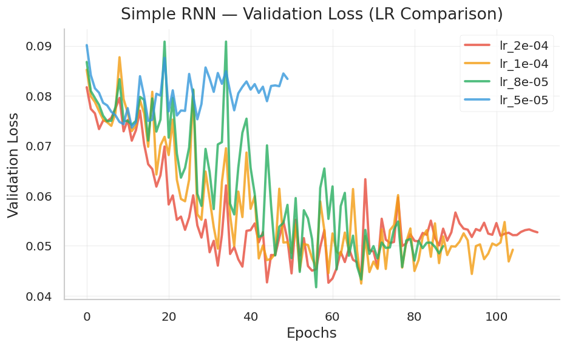

```
Saved plot: /content/drive/MyDrive/Projects/AImSecure/Laboratory2/results/images/task3_plots/simple_rnn_diagnosis.png
```

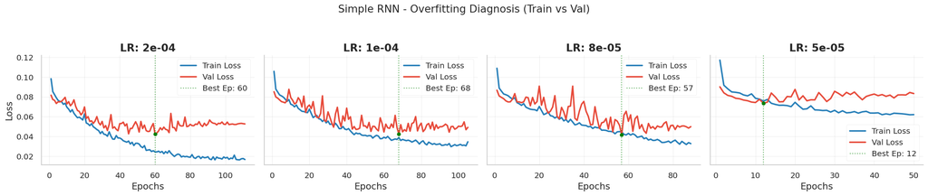

```python
# --- Plot loss curves ---

# Plot comparison
plot_lr_comparison(histories_simple, "Simple RNN", save_dir)

#Plot Train vs Validation
plot_train_val_grid(histories_simple, "Simple RNN", save_dir)
```

```
Saved plot: /content/drive/MyDrive/Projects/AImSecure/Laboratory2/results/images/task3_plots/simple_rnn_f1_comparison.png
```

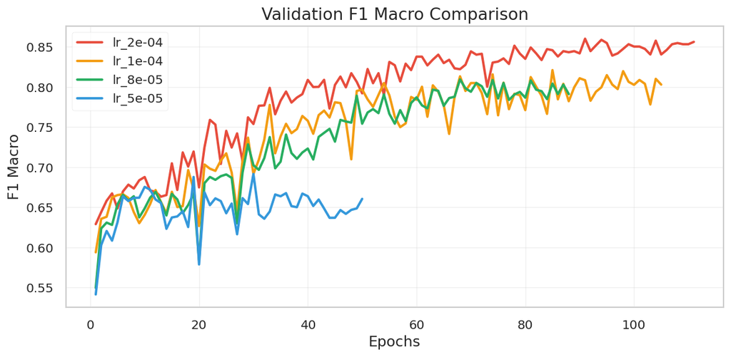

```python
# --- Plot Validation F1 Macro for Simple RNN ---
plot_training_metrics(histories_simple, save_dir=save_dir, plot_name="simple_rnn_f1_comparison")
```

```python
# --- Evaluate validation and test sets for ALL learning rates ---
print("\n" + "=" * 80)
print("Evaluation for ALL Simple RNN learning rates")
print("=" * 80)

for lr in learning_rates:
    model = models_simple[lr]

    print(f"\n{'='*60}")
    print(f"Simple RNN with lr={lr:.0e}")
    print(f"{'='*60}")

    # Validation evaluation
    y_val_true, y_val_pred = predict_loader(model, val_loader)
    print(f'\nValidation report (Simple RNN - lr={lr:.0e}):')
    print(classification_report(y_val_true, y_val_pred, digits=4, zero_division=0))

    # Test evaluation
    y_test_true, y_test_pred = predict_loader(model, test_loader)
    print(f'Test report (Simple RNN - lr={lr:.0e}):')
    print(classification_report(y_test_true, y_test_pred, digits=4, zero_division=0))

# Select the restored model using validation metrics only
best_simple_lr_value, simple_selection_table = select_best_rnn_model(
    'Simple RNN', models_simple, histories_simple, val_loader
)
best_lr_simple = (best_simple_lr_value, histories_simple[best_simple_lr_value])
print(f"\n{'='*60}")
print(
    f"Best Simple RNN - LR: {best_lr_simple[0]:.0e} "
    f"(Val Macro F1: {simple_selection_table.loc[0, 'val_macro_f1']:.4f})"
)
print(f"{'='*60}")
```

```
================================================================================
Evaluation for ALL Simple RNN learning rates
================================================================================

============================================================
Simple RNN with lr=2e-04
============================================================

Validation report (Simple RNN - lr=2e-04):
              precision    recall  f1-score   support

           0     0.7165    0.7459    0.7309       122
           1     0.9901    0.9885    0.9893      3143

    accuracy                         0.9795      3265
   macro avg     0.8533    0.8672    0.8601      3265
weighted avg     0.9799    0.9795    0.9797      3265

Test report (Simple RNN - lr=2e-04):
              precision    recall  f1-score   support

           0     0.6626    0.6626    0.6626       243
           1     0.9869    0.9869    0.9869      6262

    accuracy                         0.9748      6505
   macro avg     0.8247    0.8247    0.8247      6505
weighted avg     0.9748    0.9748    0.9748      6505


============================================================
Simple RNN with lr=1e-04
============================================================

Validation report (Simple RNN - lr=1e-04):
              precision    recall  f1-score   support

           0     0.6027    0.7213    0.6567       122
           1     0.9891    0.9815    0.9853      3143

    accuracy                         0.9718      3265
```

[output cut: 61 more lines]

```
weighted avg     0.9559    0.9622    0.9584      6505


Automatic selection for Simple RNN
Ranking criterion: validation macro F1, then validation accuracy, then checkpoint validation loss
 learning_rate  val_macro_f1  val_accuracy  checkpoint_val_loss  checkpoint_epoch
       0.00020      0.860128      0.979479             0.056651                91
       0.00010      0.821012      0.971822             0.047803                85
       0.00008      0.809435      0.969678             0.043261                68
       0.00005      0.691630      0.957734             0.085665                30
Selected Simple RNN: lr=2e-04, validation macro F1=0.8601, checkpoint epoch=91

============================================================
Best Simple RNN - LR: 2e-04 (Val Macro F1: 0.8601)
============================================================
```